# H4: Persistencia

Sección 5.6: presencia del repertorio de mercado en las fases de la Cámara, Ley 21.735

Este reporte respalda la sección 5.6 del manuscrito. H4 sostiene que, durante las fases observadas de la Ley 21.735, el repertorio asociado a la capitalización individual mantendrá su presencia en el debate. Se examinan por separado los siete conceptos del repertorio de mercado: propiedad de los fondos, capitalización individual, reciprocidad contributiva, libertad de elección, conciencia de costos, ineficiencia y riesgo estatal y previsión como mercado.

La comparación es entre las dos fases de la Cámara: enero de 2024 y enero de 2025. El Senado no se compara: sus actores son otros (solo Jara y Marcel intervienen en ambas cámaras) y sus intervenciones duplican en longitud a las de la Cámara.

Se usa la presencia, es decir, que una intervención mencione el concepto con apoyo o con rechazo, porque la estructuración se manifiesta cuando un repertorio fija los términos en que todos los actores deben argumentar, aunque sea para oponerse.

H4 se contradice si la presencia disminuye entre fases con un intervalo que excluye el cero. Si no disminuye, se informa la mayor disminución compatible con los datos (el límite inferior del intervalo), ya que no se fijó un margen de equivalencia.

## Seteo de la sesión

**Código**

```r
pacman::p_load(arrow, dplyr, tidyr, purrr, stringr, ggplot2, scales, lme4,
               parallel, igraph, ggrepel)
source("R/analysis_base.R")
source("R/apa7_word_table.R")

TABLE_DIR <- "output/tables/resultados"
FIGURE_DIR <- "output/figures/resultados"
dir.create(TABLE_DIR, recursive = TRUE, showWarnings = FALSE)
dir.create(FIGURE_DIR, recursive = TRUE, showWarnings = FALSE)
SEED <- 20261026
N_BOOT <- 1000L
N_CORES <- max(1L, detectCores() - 1L)
knitr::opts_chunk$set(cache.extra = list(tools::md5sum(c(
  "R/analysis_base.R",
  file.path(LUNA_RUN_DIR, c("annotations.parquet", "results.parquet")),
  sprintf("data/proc_data/ley_%s/coding_chunks_long.parquet", names(LAW_LABELS)),
  Sys.glob(file.path(STANCE_ADJUDICATION_DIR, "*", "decisions", "*.json")))),
  SEED, N_BOOT))

MARKET <- c("propiedad_individual_fondos", "capitalizacion_individual",
            "reciprocidad_contributiva", "libertad_eleccion_previsional",
            "conciencia_costos", "ineficiencia_estado", "prevision_como_mercado")
PHASES <- c("Cámara 2024", "Cámara 2025")
PHASE_COLORS <- setNames(c("#8c8c8c", "#2f6fa3"), PHASES)
BLOC_COLORS <- c(Izquierda = "#b03a7a", Derecha = "#12866f")
theme_set(theme_minimal(base_size = 11) +
            theme(panel.grid.minor = element_blank(),
                  panel.grid.major.y = element_blank()))
pct <- \(x) label_percent(accuracy = 1, suffix = " %")(x)
ci <- \(x) tibble(conf.low = quantile(x, 0.025, na.rm = TRUE),
                  conf.high = quantile(x, 0.975, na.rm = TRUE))
```

## Datos

La unidad es la combinación intervención sustantiva × concepto del repertorio, en las dos fases de la Cámara. La variable dependiente vale 1 si la intervención menciona el concepto, con cualquier postura.

**Código**

```r
key <- c("law_number", "document_uri", "utterance_id")
base <- load_analysis_base(LUNA_RUN_DIR)
interventions <- base$interventions |>
  filter(substantive, law_number == "21735", phase %in% PHASES) |>
  mutate(fase = factor(as.character(phase), levels = PHASES),
         bloque = factor(alignment, levels = c("izquierda", "centro", "derecha", "nonpartisan")),
         genero = factor(gender, levels = c("hombre", "mujer")),
         log_palabras = as.numeric(scale(log(utterance_words))))
claims <- base$claims |>
  filter(concept_id %in% MARKET) |>
  inner_join(interventions |> select(all_of(key)), by = key)
presence <- claims |> distinct(across(all_of(key)), concept_id) |> mutate(presencia = 1L)
model_data <- interventions |>
  select(all_of(key), speaker_id, fase, bloque, genero, log_palabras) |>
  tidyr::crossing(concept_id = MARKET) |>
  left_join(presence, by = c(key, "concept_id")) |>
  mutate(presencia = coalesce(presencia, 0L),
         concepto = factor(concept_id, levels = MARKET))
stopifnot(!anyNA(model_data$genero), !anyNA(model_data$bloque))
both_phases <- interventions |>
  distinct(speaker_id, fase) |>
  count(speaker_id) |>
  filter(n == 2) |>
  nrow()
interventions |>
  group_by(fase) |>
  summarise(intervenciones = n(), actores = n_distinct(speaker_id),
            palabras_mediana = median(utterance_words)) |>
  knitr::kable()
```

| fase | intervenciones | actores | palabras_mediana |
| --- | --- | --- | --- |
| Cámara 2024 | 137 | 108 | 424 |
| Cámara 2025 | 149 | 131 | 438 |

94 actores intervienen en ambas fases de la Cámara, incluidos los ministros Jara y Marcel.

**Código**

```r
observed <- model_data |>
  group_by(fase, concept_id) |>
  summarise(presencia = mean(presencia), .groups = "drop") |>
  pivot_wider(names_from = fase, values_from = presencia) |>
  mutate(concepto = CONCEPT_SHORT[concept_id])
observed |>
  transmute(concepto, across(all_of(PHASES), \(x) 100 * x)) |>
  knitr::kable(digits = 1, caption = "Presencia observada (% de intervenciones)")
```

Presencia observada (% de intervenciones)

| concepto | Cámara 2024 | Cámara 2025 |
| --- | --- | --- |
| Capitalización individual | 28.5 | 25.5 |
| Conciencia de costos | 16.8 | 16.1 |
| Ineficiencia y riesgo estatal | 26.3 | 23.5 |
| Libertad de elección | 16.1 | 16.1 |
| Previsión como mercado | 43.8 | 59.1 |
| Propiedad de los fondos | 27.0 | 33.6 |
| Reciprocidad contributiva | 34.3 | 35.6 |

## Modelo

Un logit multinivel con el concepto, la fase y su interacción como efectos fijos:

```
presencia ~ concepto * fase + bloque + genero + log_palabras + (1 | actor)
```

A diferencia de H1, la interacción concepto × fase no se trata como efecto aleatorio. Todos los conceptos aparecen en ambas fases, de modo que no hay celdas sin casos que estabilizar, y con solo siete conceptos la varianza de ese efecto se estima casi nula, lo que encoge los cambios de cada concepto hacia el promedio (en una primera estimación, la previsión como mercado pasaba de un cambio observado de 15 pp a uno estimado de 3 pp). El bloque entra solo como control: la proporción de actores de cada bloque cambia entre fases, y sin el control un cambio en quién habla se confundiría con un cambio en el repertorio. El intercepto por actor recoge que muchos actores intervienen en ambas fases.

**Código**

```r
control <- glmerControl(optimizer = "bobyqa", optCtrl = list(maxfun = 1e5))
formula_h4 <- presencia ~ concepto * fase + bloque + genero + log_palabras + (1 | speaker_id)
fit_h4 <- function(data) glmer(formula_h4, data = data, family = binomial, control = control)
m_h4 <- fit_h4(model_data)
```

**Código**

```r
sd_re <- map_dbl(VarCorr(m_h4), \(v) attr(v, "stddev"))
tibble(observaciones = nobs(m_h4), singular = isSingular(m_h4),
       avisos = length(m_h4@optinfo$conv$lme4$messages),
       de_actor = sd_re[["speaker_id"]]) |>
  knitr::kable(digits = 2)
```

| observaciones | singular | avisos | de_actor |
| --- | --- | --- | --- |
| 2002 | FALSE | 0 | 0.33 |

## Probabilidades predichas e intervalos

Para cada concepto y fase, la probabilidad predicha promedia las predicciones sobre todas las intervenciones observadas, asignadas a esa fase y conservando su bloque, género y longitud, con el efecto del actor en cero. La presencia del repertorio es el promedio de los siete conceptos. Los intervalos provienen de 1000 remuestreos de actores con todas sus intervenciones de ambas fases y reajuste del modelo.

**Código**

```r
predict_h4 <- function(m, data) {
  by_concept <- map(PHASES, \(f) {
    nd <- mutate(data, fase = factor(f, levels = PHASES))
    tibble(concepto = nd$concepto,
           p = predict(m, nd, type = "response", re.form = NA)) |>
      group_by(concepto) |>
      summarise(estimate = mean(p), .groups = "drop") |>
      mutate(fase = f)
  }) |>
    list_rbind() |>
    mutate(concepto = as.character(concepto))
  # La presencia del repertorio es el promedio de los siete conceptos.
  repertoire <- by_concept |>
    group_by(fase) |>
    summarise(estimate = mean(estimate)) |>
    mutate(concepto = "repertorio")
  bind_rows(by_concept, repertoire)
}
boot_h4 <- function(data) {
  actors <- distinct(data, speaker_id)
  mclapply(seq_len(N_BOOT), \(i) {
    set.seed(SEED + i)
    boot_data <- actors |>
      slice_sample(prop = 1, replace = TRUE) |>
      mutate(boot_id = paste0("a", row_number())) |>
      inner_join(data, by = "speaker_id", relationship = "many-to-many") |>
      mutate(speaker_id = boot_id)
    m <- tryCatch(suppressMessages(suppressWarnings(fit_h4(boot_data))), error = \(e) NULL)
    if (is.null(m)) return(NULL)
    predict_h4(m, boot_data) |> mutate(replica = i)
  }, mc.cores = N_CORES) |>
    list_rbind()
}
```

**Código**

```r
boot_reps <- boot_h4(model_data)
```

**Código**

```r
point <- predict_h4(m_h4, model_data)
predictions_h4 <- point |>
  left_join(boot_reps |> group_by(concepto, fase) |> reframe(ci(estimate)),
            by = c("concepto", "fase"))
change_h4 <- boot_reps |>
  pivot_wider(names_from = fase, values_from = estimate) |>
  mutate(diferencia = `Cámara 2025` - `Cámara 2024`) |>
  group_by(concepto) |>
  reframe(ci(diferencia)) |>
  left_join(point |> pivot_wider(names_from = fase, values_from = estimate) |>
              mutate(estimate = `Cámara 2025` - `Cámara 2024`), by = "concepto")
label_h4 <- \(d) d |>
  mutate(etiqueta = if_else(concepto == "repertorio", "Repertorio (promedio)",
                            unname(CONCEPT_SHORT[concepto])))
predictions_h4 <- label_h4(predictions_h4)
change_h4 <- label_h4(change_h4)
write_parquet(predictions_h4, file.path(TABLE_DIR, "h4_predicciones.parquet"))
write_parquet(change_h4, file.path(TABLE_DIR, "h4_cambios.parquet"))
cat("Réplicas completadas:", n_distinct(boot_reps$replica), "\n")
```

```
Réplicas completadas: 1000
```

**Código**

```r
change_h4 |>
  transmute(etiqueta, `Cámara 2024` = 100 * `Cámara 2024`, `Cámara 2025` = 100 * `Cámara 2025`,
            diferencia = 100 * estimate, ic_inf = 100 * conf.low, ic_sup = 100 * conf.high) |>
  arrange(desc(etiqueta == "Repertorio (promedio)"), diferencia) |>
  knitr::kable(digits = 1, caption = "Probabilidad predicha de presencia (%) y cambio 2025 − 2024 (pp)")
```

Probabilidad predicha de presencia (%) y cambio 2025 − 2024 (pp)

| etiqueta | Cámara 2024 | Cámara 2025 | diferencia | ic_inf | ic_sup |
| --- | --- | --- | --- | --- | --- |
| Repertorio (promedio) | 28.3 | 28.8 | 0.5 | -3.4 | 4.3 |
| Capitalización individual | 29.3 | 24.3 | -5.0 | -13.7 | 3.6 |
| Ineficiencia y riesgo estatal | 27.0 | 22.3 | -4.7 | -13.9 | 5.0 |
| Conciencia de costos | 17.1 | 15.1 | -2.0 | -10.7 | 5.7 |
| Libertad de elección | 16.4 | 15.1 | -1.2 | -10.4 | 7.3 |
| Reciprocidad contributiva | 35.4 | 34.2 | -1.1 | -11.2 | 8.8 |
| Propiedad de los fondos | 27.7 | 32.2 | 4.5 | -4.6 | 13.5 |
| Previsión como mercado | 45.3 | 57.9 | 12.7 | 0.9 | 23.1 |

## Alternativas de visualización

### A. Puntos unidos por concepto, como las figuras de H1 y H2

**Código**

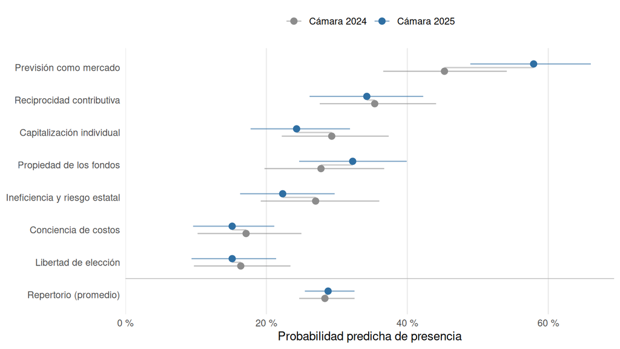

Figura 1: Alternativa A. Probabilidad predicha de que una intervención mencione cada concepto del repertorio de mercado, fases de la Cámara

```r
order_a <- predictions_h4 |>
  filter(fase == "Cámara 2024", concepto != "repertorio") |>
  arrange(estimate) |>
  pull(etiqueta)
plot_a <- predictions_h4 |>
  mutate(etiqueta = factor(etiqueta, levels = c("Repertorio (promedio)", order_a)),
         fase = factor(fase, levels = PHASES))
fig_a <- ggplot(plot_a, aes(x = estimate, y = etiqueta, color = fase)) +
  geom_line(aes(group = etiqueta), color = "grey80", linewidth = 0.6) +
  geom_errorbar(aes(xmin = conf.low, xmax = conf.high), width = 0, orientation = "y",
                linewidth = 0.5, alpha = 0.6, position = position_dodge(width = 0.45)) +
  geom_point(size = 2.5, position = position_dodge(width = 0.45)) +
  geom_hline(yintercept = 1.5, color = "grey70", linewidth = 0.3) +
  scale_x_continuous(labels = pct, limits = c(0, NA), expand = expansion(mult = c(0, 0.05))) +
  scale_color_manual(values = PHASE_COLORS) +
  labs(x = "Probabilidad predicha de presencia", y = NULL, color = NULL) +
  theme(legend.position = "top")
print(fig_a)
ggsave(file.path(FIGURE_DIR, "figura11_h4_presencia.png"), fig_a,
       width = 8, height = 4.5, dpi = 300, bg = "white")
```

### B. Cambio entre fases con su intervalo

Muestra directamente el contraste de H4: una disminución con un intervalo bajo cero contradice la hipótesis.

**Código**

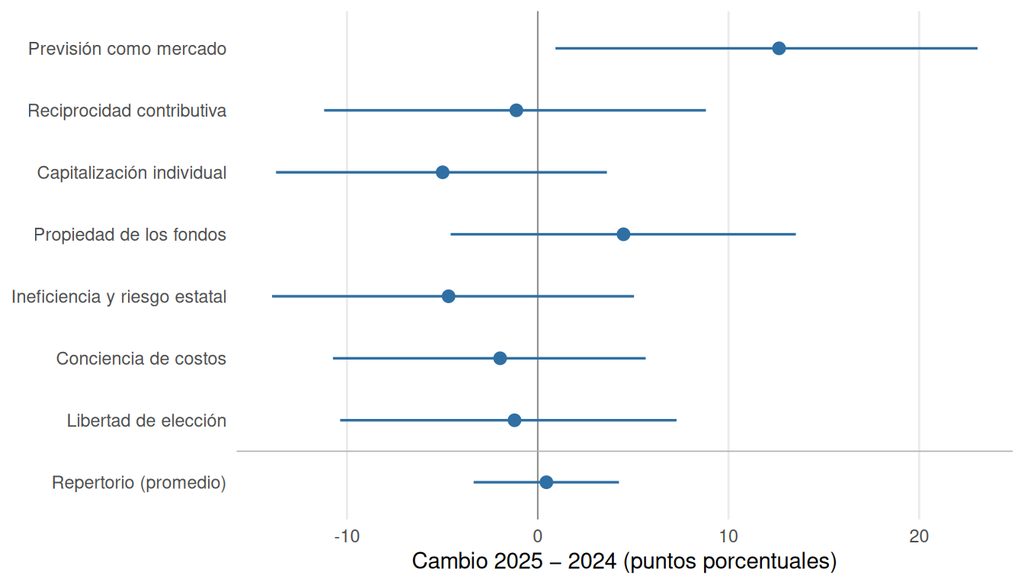

Figura 2: Alternativa B. Cambio en la probabilidad predicha de presencia entre la Cámara de 2024 y la de 2025

```r
plot_b <- change_h4 |>
  mutate(etiqueta = factor(etiqueta, levels = c("Repertorio (promedio)", order_a)),
         across(c(estimate, conf.low, conf.high), \(x) 100 * x))
fig_b <- ggplot(plot_b, aes(x = estimate, y = etiqueta)) +
  geom_vline(xintercept = 0, color = "grey50", linewidth = 0.3) +
  geom_errorbar(aes(xmin = conf.low, xmax = conf.high), width = 0, orientation = "y",
                linewidth = 0.6, color = "#2f6fa3") +
  geom_point(size = 2.5, color = "#2f6fa3") +
  geom_hline(yintercept = 1.5, color = "grey70", linewidth = 0.3) +
  labs(x = "Cambio 2025 − 2024 (puntos porcentuales)", y = NULL)
print(fig_b)
ggsave(file.path(FIGURE_DIR, "figura11_h4_alternativa_b.png"), fig_b,
       width = 7, height = 4, dpi = 300, bg = "white")
```

### C. Presencia observada por bloque

Descriptiva, sin modelo: muestra si la izquierda y la derecha usan el repertorio en proporciones parecidas en ambas fases. Sirve para los pasajes de estructuración, porque permite ver si la izquierda sigue debatiendo en los términos del repertorio.

**Código**

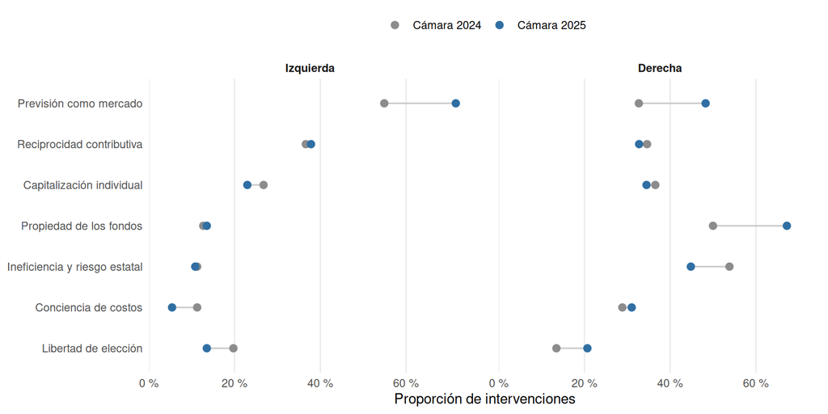

Figura 3: Alternativa C. Proporción observada de intervenciones que mencionan cada concepto, por bloque y fase de la Cámara

```r
plot_c <- model_data |>
  filter(bloque %in% c("izquierda", "derecha")) |>
  group_by(bloque, fase, concept_id) |>
  summarise(presencia = mean(presencia), .groups = "drop") |>
  mutate(bloque = factor(str_to_title(as.character(bloque)), levels = names(BLOC_COLORS)),
         etiqueta = factor(CONCEPT_SHORT[concept_id], levels = order_a))
fig_c <- ggplot(plot_c, aes(x = presencia, y = etiqueta, color = fase)) +
  geom_line(aes(group = etiqueta), color = "grey80", linewidth = 0.6) +
  geom_point(size = 2.4) +
  facet_wrap(~ bloque) +
  scale_x_continuous(labels = pct, limits = c(0, NA), expand = expansion(mult = c(0, 0.05))) +
  scale_color_manual(values = PHASE_COLORS) +
  labs(x = "Proporción de intervenciones", y = NULL, color = NULL) +
  theme(legend.position = "top", strip.text = element_text(face = "bold"),
        panel.spacing.x = unit(1.5, "lines"))
print(fig_c)
ggsave(file.path(FIGURE_DIR, "figura12_h4_bloques.png"), fig_c,
       width = 9, height = 4.5, dpi = 300, bg = "white")
```

### D. Redes de congruencia de conceptos por fase

Como la Figura 8, pero una red por fase con la misma disposición. Incluye los 13 conceptos analizados (sin actitud), destaca los del repertorio de mercado y muestra los vínculos con peso de al menos 0,30. Permite ver si el repertorio cambia de posición respecto de los demás conceptos.

**Código**

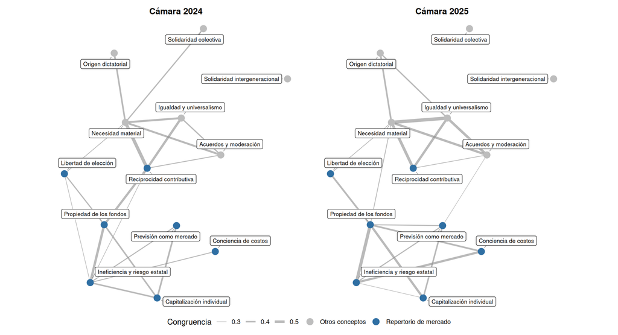

Figura 4: Alternativa D. Redes de congruencia entre conceptos por fase de la Cámara

```r
all_concepts <- setdiff(sort(unique(base$claims$concept_id)), "actitud")
phase_claims <- base$claims |>
  filter(concept_id %in% all_concepts) |>
  inner_join(interventions |> select(all_of(key), speaker_id, fase), by = key) |>
  distinct(fase, speaker_id, concept_id, stance)
congruence_of <- function(cl) {
  ids <- sort(unique(cl$speaker_id))
  build <- function(s) {
    m <- matrix(0, length(ids), length(all_concepts), dimnames = list(ids, all_concepts))
    r <- filter(cl, stance == s)
    m[cbind(match(r$speaker_id, ids), match(r$concept_id, all_concepts))] <- 1
    m
  }
  sup <- build("support")
  opp <- build("oppose")
  norm <- sqrt(colSums(sup^2 + opp^2))
  w <- (crossprod(sup) + crossprod(opp)) / outer(norm, norm)
  w[!is.finite(w)] <- 0
  diag(w) <- 0
  w
}
weights_by_phase <- map(set_names(PHASES), \(f) congruence_of(filter(phase_claims, fase == f)))
pairs_by_phase <- imap_dfr(weights_by_phase, \(w, f) {
  as_tibble(t(combn(all_concepts, 2)), .name_repair = "minimal") |>
    setNames(c("from", "to")) |>
    mutate(weight = w[cbind(from, to)], fase = f)
})
layout_graph <- graph_from_data_frame(
  pairs_by_phase |> group_by(from, to) |> summarise(weight = mean(weight), .groups = "drop") |>
    filter(weight > 0),
  directed = FALSE, vertices = tibble(name = all_concepts))
set.seed(SEED)
layout_d <- layout_with_fr(layout_graph, weights = E(layout_graph)$weight, niter = 3000)
nodes_d <- tibble(concept_id = all_concepts, x = layout_d[, 1], y = layout_d[, 2]) |>
  mutate(concepto = unname(CONCEPT_SHORT[concept_id]),
         grupo = if_else(concept_id %in% MARKET, "Repertorio de mercado", "Otros conceptos")) |>
  tidyr::crossing(fase = PHASES)
edges_d <- pairs_by_phase |>
  filter(weight >= 0.30) |>
  mutate(x = layout_d[match(from, all_concepts), 1], y = layout_d[match(from, all_concepts), 2],
         xend = layout_d[match(to, all_concepts), 1], yend = layout_d[match(to, all_concepts), 2])
fig_d <- ggplot() +
  geom_segment(data = edges_d, aes(x = x, y = y, xend = xend, yend = yend, linewidth = weight),
               color = "grey55", alpha = 0.6) +
  geom_point(data = nodes_d, aes(x = x, y = y, color = grupo), size = 4) +
  geom_label_repel(data = nodes_d, aes(x = x, y = y, label = concepto), size = 2.8, seed = SEED,
                   box.padding = 0.5, point.padding = 0.4, label.size = 0.15,
                   min.segment.length = 0, segment.color = "grey55", segment.size = 0.3,
                   max.overlaps = Inf) +
  facet_wrap(~ fase) +
  scale_linewidth(range = c(0.3, 2.2), limits = c(0.30, NA), name = "Congruencia") +
  scale_color_manual(values = c(`Repertorio de mercado` = "#2f6fa3", `Otros conceptos` = "#bdbdbd"),
                     name = NULL) +
  coord_equal(clip = "off") +
  theme_void() +
  theme(legend.position = "bottom", strip.text = element_text(face = "bold", size = 12),
        panel.spacing = unit(2, "lines"),
        plot.background = element_rect(fill = "white", color = NA),
        plot.margin = margin(10, 20, 10, 20))
print(fig_d)
ggsave(file.path(FIGURE_DIR, "figura11_h4_alternativa_d.png"), fig_d,
       width = 12, height = 6.5, dpi = 300, bg = "white")
```

## Tabla para el anexo

La tabla presenta la probabilidad predicha de presencia de cada concepto y del repertorio en cada fase y su cambio. Los coeficientes no se reportan; la especificación está en el Anexo 4.

**Código**

```r
dec <- function(x, digits = 1) formatC(round(x, digits) + 0, format = "f", digits = digits, decimal.mark = ",")
ic_txt <- function(est, low, high, digits = 1) {
  paste0(dec(est, digits), " [", dec(low, digits), "; ", dec(high, digits), "]") |>
    str_replace_all("-", "−")
}
tabla_h4 <- change_h4 |>
  mutate(orden = if_else(concepto == "repertorio", 0L, 1L)) |>
  left_join(predictions_h4 |>
              mutate(valor = ic_txt(100 * estimate, 100 * conf.low, 100 * conf.high)) |>
              select(concepto, fase, valor) |>
              pivot_wider(names_from = fase, values_from = valor, names_prefix = "txt_"),
            by = "concepto") |>
  arrange(orden, desc(estimate)) |>
  transmute(fila = etiqueta, c1 = `txt_Cámara 2024`, c2 = `txt_Cámara 2025`,
            c3 = ic_txt(100 * estimate, 100 * conf.low, 100 * conf.high))
export_apa7_word_table(
  tabla_h4, file.path(TABLE_DIR, "anexo_h4_presencia.docx"),
  "Probabilidad predicha de presencia de los conceptos del repertorio de mercado por fase de la Cámara, Ley N.º 21.735",
  note = paste0(
    "Probabilidad predicha (%) de que una intervención sustantiva mencione cada concepto, con ",
    "apoyo o rechazo, a partir de un modelo logístico multinivel, e intervalos de confianza ",
    "del 95 % entre corchetes, obtenidos con 1.000 remuestreos de actores. El repertorio ",
    "corresponde al promedio de los siete conceptos. Δ corresponde a 2025 menos 2024, en ",
    "puntos porcentuales. ", format(nobs(m_h4), big.mark = "."),
    " observaciones (intervención × concepto) de ", nrow(interventions), " intervenciones y ",
    ngrps(m_h4)[["speaker_id"]], " actores. La especificación se presenta en el Anexo 4."),
  table_number = 8L, body_font_size = 11,
  header_labels = c("Concepto", "Cámara 2024", "Cámara 2025", "Δ (pp)"))
```

**Código**

```r
knitr::kable(tabla_h4)
```

| fila | c1 | c2 | c3 |
| --- | --- | --- | --- |
| Repertorio (promedio) | 28,3 [24,7; 32,5] | 28,8 [25,5; 32,5] | 0,5 [−3,4; 4,3] |
| Previsión como mercado | 45,3 [36,6; 54,1] | 57,9 [48,9; 66,0] | 12,7 [0,9; 23,1] |
| Propiedad de los fondos | 27,7 [19,7; 36,7] | 32,2 [24,6; 39,9] | 4,5 [−4,6; 13,5] |
| Reciprocidad contributiva | 35,4 [27,6; 44,1] | 34,2 [26,1; 42,3] | −1,1 [−11,2; 8,8] |
| Libertad de elección | 16,4 [9,7; 23,4] | 15,1 [9,4; 21,4] | −1,2 [−10,4; 7,3] |
| Conciencia de costos | 17,1 [10,2; 25,0] | 15,1 [9,6; 21,1] | −2,0 [−10,7; 5,7] |
| Ineficiencia y riesgo estatal | 27,0 [19,2; 36,0] | 22,3 [16,3; 29,7] | −4,7 [−13,9; 5,0] |
| Capitalización individual | 29,3 [22,2; 37,4] | 24,3 [17,8; 31,9] | −5,0 [−13,7; 3,6] |

## Declaraciones de la izquierda sobre el repertorio

Para seleccionar los pasajes de estructuración, se listan las declaraciones de actores de izquierda sobre conceptos del repertorio en cada fase de la Cámara, con su postura y la cita del modelo.

**Código**

```r
raw <- arrow::read_parquet(file.path(LUNA_RUN_DIR, "annotations.parquet"))
left_blocks <- base$blocks |>
  filter(substantive, law_number == "21735", alignment == "izquierda",
         unit_id %in% raw$unit_id) |>
  mutate(fase = PHASE_LABELS[date]) |>
  filter(fase %in% PHASES) |>
  select(unit_id, utterance_id, party, role, fase)
left_statements <- raw |>
  filter(concept_id %in% MARKET) |>
  inner_join(left_blocks, by = c("unit_id", "utterance_id")) |>
  semi_join(claims, by = c("utterance_id", "concept_id", "stance")) |>
  transmute(fase, partido = party, concepto = CONCEPT_SHORT[concept_id],
            postura = if_else(stance == "support", "Apoyo", "Rechazo"), cita = evidence_text) |>
  arrange(fase, concepto, postura)
left_statements |> count(fase, concepto, postura) |>
  pivot_wider(names_from = c(fase, postura), values_from = n, values_fill = 0) |>
  knitr::kable(caption = "Declaraciones de izquierda sobre el repertorio, por fase y postura") |>
  print()
```

Declaraciones de izquierda sobre el repertorio, por fase y postura

| concepto | Cámara 2024_Rechazo | Cámara 2024_Apoyo | Cámara 2025_Apoyo | Cámara 2025_Rechazo |
| --- | --- | --- | --- | --- |
| Capitalización individual | 29 | 0 | 1 | 18 |
| Conciencia de costos | 3 | 7 | 3 | 3 |
| Ineficiencia y riesgo estatal | 9 | 0 | 1 | 10 |
| Libertad de elección | 3 | 18 | 13 | 0 |
| Previsión como mercado | 64 | 10 | 24 | 81 |
| Propiedad de los fondos | 3 | 6 | 7 | 2 |
| Reciprocidad contributiva | 0 | 39 | 42 | 0 |

**Código**

```r
write_parquet(left_statements, file.path(TABLE_DIR, "h4_declaraciones_izquierda.parquet"))
# Las citas largas rompen una tabla: se listan por concepto, postura y fase, y se
# guardan también en un Markdown aparte para leerlas.
listing <- left_statements |>
  group_by(concepto, postura, fase) |>
  group_map(\(d, k) c(sprintf("\n### %s · %s · %s (%d)\n", k$concepto, k$postura, k$fase, nrow(d)),
                      sprintf("- «%s» (%s)", str_squish(d$cita), d$partido))) |>
  unlist()
cat(listing, sep = "\n")
```

### Capitalización individual · Apoyo · Cámara 2025 (1)

- «este proyecto es positivo, porque aumenta la PGU, asegura el ahorro individual» (Partido Liberal de Chile)

### Capitalización individual · Rechazo · Cámara 2024 (29)

- «La pensión autofinanciada de las AFP para la mitad de las mujeres de Chile es de 38.000 pesos, la que con PGU, es decir, con aporte directo del Estado, llega a 244.000 pesos, una cifra que apenas se empina sobre la línea de la pobreza. En los hechos, las AFP nos castigan por dar vida, por criar y por vivir mucho. Se nos castiga por el hecho de ser mujeres.» (Partido Comunista de Chile)
- «la AFP le paga una pensión autofinanciada de 70.000 pesos. Con los 70.000 pesos que recibe de la AFP tiene la libertad de elegir entre dos kilos de pollo, arroz, lentejas, algo de queso para el desayuno o un par de zapatos que reemplacen a los que usa desde hace dos años. Con esa pensión tiene garantizada la propiedad de unos cuantos kilos de papas que, seguramente, se esfumarán en un par de semanas.» (Partido Comunista de Chile)
- «Para los chilenos las AFP resultaron un estrepitoso fracaso. Varias generaciones de trabajadores han sido condenadas a la pobreza. En la Región de Valparaíso, el 50 por ciento de las mujeres jubiladas recibe una pensión autofinanciada de 71.000 pesos.» (Partido Comunista de Chile)
- «Mienten descaradamente cuando dicen que destinar el 6 por ciento a la cuenta individual va a mejorar las pensiones.» (Partido Comunista de Chile)
- «La única forma de revertir la crisis del componente contributivo del sistema de pensiones en Chile es con una disminución relevante del componente de cuentas individuales» (Partido Comunista de Chile)
- «un modelo que evidentemente fracasó; y fracasó, en términos simples, porque la premisa que levantaron sus creadores no se ha cumplido. Los trabajadores y trabajadoras no reciben un monto ni siquiera similar al de las remuneraciones que tenían durante su etapa laboral.» (Partido Comunista de Chile)
- «es un parche porque las AFP pagan pensiones miserables. El 96 por ciento de las mujeres que se jubilaron en el último año tiene una pensión menor al sueldo mínimo. Pero hay otra cifra peor: la mitad de las mujeres se autofinancian su pensión con 40 lucas.» (Partido Convergencia Social)
- «en el caso de los hombres financian un 27 por ciento, que no alcanza realmente a cubrir lo que están recibiendo de pensiones.» (Partido Comunista de Chile)
- «Un sistema basado solo en la capitalización individual no reconoce el trabajo de cuidados, que es indispensable para una sociedad.» (Partido Convergencia Social)
- «un 6 por ciento en las cuentas individuales ciertamente mejora las pensiones de quienes hoy están bien o tendrán buenas jubilaciones, pero no las de quienes tienen problemas.» (Partido Radical Socialdemócrata)
- «Cuando se instaló el sistema de capitalización individual, las AFP prometieron mejorar la vida de los chilenos, con pensiones espectaculares que nunca llegaron. Y aquí estamos, cuarenta y dos años después, en una crisis total del sistema previsional.» (Partido Comunista de Chile)
- «Todos sabemos que el sistema de capitalización individual fue un fracaso para pagar pensiones mínimamente decentes.» (Partido Liberal de Chile)
- «el ahorro individual es insuficiente» (Partido Liberal de Chile)
- «Es ideológico, en primer lugar, porque se trata de dar un primer paso hacia un sistema más justo o con vías a la solidaridad previsional. Digo “un primer paso”, porque no hay un cambio sustantivo a la lógica de terminar con la capitalización individual, si bien se avanza hacia ese norte.» (Partido Comunista de Chile)
- «El problema es que no avancemos solo en capitalización individual, sino que se suba la pensión mediante una pensión garantizada que no dependa directamente de cuánto pudiste trabajar en tu vida y que establezca más bien un piso de seguridad social.» (Revolución Democrática)
- «Por eso debemos incorporar solidaridad, porque las pensiones de la gente, de las mujeres, de los actuales pensionados, así como de los del futuro serán más altas que las que les corresponderían si consideráramos solo su remuneración.» (Revolución Democrática)
- «Si bien la actual estructura del sistema otorga pensiones a quienes han contribuido a este e incluye aspectos valorados socialmente, como la propiedad de los recursos cotizados por las y los trabajadores, resulta incapaz de otorgar pensiones suficientes, exponiendo individualmente a las personas afiliadas a decisiones complejas» (Revolución Democrática)
- «En sus fundamentos, reconociendo que el sistema de capitalización individual no logra por sí solo cubrir los riesgos inherentes a las personas ni prevenir el riesgo de pobreza en la vejez» (Partido Convergencia Social)
- «el sistema de pensiones, en el que solo de manera individual las personas deben resolver su vida. Pero los datos nos dicen que la forma de resolver esa vida es realmente dramática.» (Partido Comunista de Chile)
- «para el sistema de pensiones, que, en su vertiente contributiva, en la que se cotiza, genera pensiones que no alcanzan ni para la más mínima subsistencia.» (Partido Comunista de Chile)
- «vino a subsidiar el drama de las pensiones que se otorgan a partir de la implementación del sistema de capitalización individual administrado por las AFP.» (Partido Comunista de Chile)
- «pérdidas tremendas en sus cuentas, en sus saldos, que, incluso, les han impedido poder jubilar, y han tenido que seguir trabajando hasta cuando ya no dan más. El rol de un sistema de pensiones también es mitigar la exposición a esos riesgos.» (Partido Comunista de Chile)
- «en un modelo comparativo entre un 3-3 versus todo para capitalización individual, hay que tener presente que recién en 2070 se verán incrementadas las tasas de reemplazo. Ese el drama que tenemos.» (Partido Comunista de Chile)
- «nuestro mal denominado sistema de seguridad social ha descansado única y exclusivamente en el ahorro individual, es decir, en el lema “rasquémonos con nuestras propias uñas”, sin incorporar ningún elemento de certeza que otorgue, además, pensiones por sobre la línea de pobreza.» (Partido Por la Democracia)
- «En todos los lugares en los que se ha aplicado el modelo de capitalización individual sin factores de solidaridad, este ha dejado solo pensiones de hambre y miseria.» (Partido Humanista)
- «siguen defendiendo algo que genera tanto daño a las y los trabajadores, y a los pensionados» (Partido Humanista)
- «¿De qué les sirve a las personas cuidadoras, a quienes se enfermaron o a quienes por algún motivo, sin querer, tienen grandes lagunas previsionales? Mantener el 6 por ciento en capitalización individual no es solidario» (Partido Ecologista Verde de Chile)
- «lo deficiente que es un sistema basado solamente en la capitalización individual.» (Partido Convergencia Social)
- «Si cada uno se rasca solamente con sus propias uñas, sin contar el Pilar Solidario y la PGU, la pensión en hombres se estima en aproximadamente 159.000 pesos, y la de las mujeres solo en alrededor de 38.000 pesos. ¿Cuántos de ustedes, diputados y diputadas, pueden vivir con eso?» (Partido Convergencia Social)

### Capitalización individual · Rechazo · Cámara 2025 (18)

- «Esta situación, que es una buena noticia para la población, para la longevidad, para el estado de las personas en nuestro país, hoy en el sistema de pensiones se castiga, puesto que se ha instalado una lógica individual, que es algo que debemos compensar dándole mixtura.» (Partido Comunista de Chile)
- «No puede eliminar el riesgo de pobreza en la vejez, porque, cuando un sistema de pensiones se basa solo en los ahorros de las personas, considerando que aquellas de menores ingresos tienden a tener mayores lagunas previsionales, en realidad se exacerban esas diferencias, y se exacerba el riesgo de pobreza en la vejez.» (Partido Socialista de Chile)
- «Un sistema así tampoco puede mitigar riesgos, porque uno no le puede pedir a una persona que, si se invalida a los 40 años de edad, financie su pensión solo con los ahorros que ha logrado acumular.» (Partido Socialista de Chile)
- «Nosotros hemos tenido un sistema de pensiones que, por lo menos en sus primeras décadas de existencia, se afirmó solamente en un pilar de capitalización individual, y por esa razón no pudo cumplir con ninguno de sus tres objetivos.» (Partido Socialista de Chile)
- «La mediana de la pensión autofinanciada, en el caso de los hombres, es de 153.000 pesos, mientras que, en el caso de las mujeres, solo alcanza -escuchen con atención, por favor a 38.158 pesos. Si aquello no es sinónimo de fracaso o abuso, díganme ustedes qué es.» (Partido Frente Amplio)
- «Con este proyecto, con la reforma del Presidente Boric , las pensiones de los chilenos y chilenas subirán. Esto no será gracias a la capitalización individual ni menos gracias a las AFP, sino gracias al aporte estatal y a la solidaridad» (Partido Frente Amplio)
- «El actual modelo de AFP demostró ser insuficiente y desigual. Debemos considerar alternativas que permitan que efectivamente estos fondos se inviertan en beneficio directo de la sociedad, como sucedía antes de 1973, cuando el Estado utilizaba estos recursos para financiar obra pública, garantizando siempre su devolución en un sistema tripartito y de reparto.» (Partido Comunista de Chile)
- «que tiene a la mitad de los jubilados de nuestro país recibiendo pensiones autofinanciadas de menos de 250.000 pesos mensuales» (Partido Por la Democracia)
- «El modelo de capitalización individual, diseñado sin ninguna lógica de solidaridad, fracasó rotundamente. No es casualidad que el 90 por ciento de las pensiones autofinanciadas, es decir, aquellas que entregan las AFP, sean inferiores a 155.000 pesos para los hombres y a 46.000 pesos para las mujeres» (Partido Comunista de Chile)
- «no se garantiza un futuro digno para los jubilados que seguirán dependiendo del aporte del Estado para suplir la ineficiencia del sistema de capitalización individual.» (Partido Comunista de Chile)
- «se reconoce la larga injusticia contra las mujeres y las lagunas que tienen por la labor de cuidados. Todo eso que hoy podemos pequeñamente subsanar se llama seguridad social, la seguridad social que no permite el sistema de capitalización individual, que tanto daño ha causado a nuestro país.» (Partido Por la Democracia)
- «Jamás las pensiones han aumentado por efecto del ahorro individual, menos por las AFP.» (Partido Comunista de Chile)
- «prevalecen las cuentas individuales, a diferencia de otras legislaciones en que la mayor parte de las cotizaciones va a seguridad social. Esperamos que eso cambie y que, en algún momento, al hacernos cargo, avancemos hacia un sistema de seguridad social real» (Partido Comunista de Chile)
- «la propuesta original de la derecha de destinar los seis puntos a cuentas individuales -eso señalaban en un comienzo significaría que las pensiones iban a subir en treinta años más. Si las pensiones van a subir este año 2025 con la aprobación de esta reforma, es por la PGU y por la solidaridad en la cual insistieron el gobierno y el oficialismo.» (Partido Frente Amplio)
- «una pensión autofinanciada menor a 60.000 pesos en el caso de los hombres, y rozando los 50.000 pesos en el caso de las mujeres.» (Partido Socialista de Chile)
- «Y este problema es respecto del modelo de capitalización individual, que carga en los hombros de los trabajadores toda la responsabilidad de su jubilación.» (Partido Frente Amplio)
- «Es por eso que la capitalización individual no es una respuesta para las mujeres. La capitalización individual, como única base de un sistema, es ineficiente y es profundamente injusta.» (Partido Frente Amplio)
- «Esa mujer hoy día recibe casi 290.000 pesos, pero -¡ojo!solo 72.000 pesos de su AFP. Lamentablemente, este no es un caso excepcional. La mediana de lo que reciben las mujeres por la AFP es de 48.000 pesos» (Partido Frente Amplio)

### Conciencia de costos · Apoyo · Cámara 2024 (7)

- «sí tenían diferencias en torno al tema del financiamiento, porque efectivamente faltaban fuentes de financiamiento» (Partido Comunista de Chile)
- «en beneficios para fortalecer el bono por hijo, y que ahora ya no puede ir, porque no hay cómo pagarlo» (Partido Comunista de Chile)
- «en beneficios para fortalecer el empleo y la formalidad, que ahora tampoco puede ir, en particular de las mujeres, porque al disminuir el seguro social tampoco hay cómo pagarlo» (Partido Comunista de Chile)
- «respecto de esta reforma, ha montado la derecha, cuyos representantes sostienen testarudamente que no es justa ni sostenible.» (Partido Comunes)
- «que el aumento para los actuales pensionados es vía PGU, pero proponen hacerlo con dinero invisible.» (Partido Ecologista Verde de Chile)
- «Para ponerle aritmética a este asunto, si queremos hacer el cálculo de cuánto significa no financiar con el mecanismo de seguro o con el cumplimiento de obligaciones tributarias, que genera mayor recaudación, significa que en un lapso de tres años habremos superado largamente el límite de deuda que está en nuestra regla fiscal y que en diez años estaremos con una deuda pública del orden del 70 por ciento del producto interno bruto. En concreto, eso es lo que cualquier experto les va a decir. En ese sentido, cuando hablamos de aumentar la PGU ahora sin letra chica, significa aumentar la PGU sin financiamiento.» (Partido Socialista de Chile)
- «aprobar la PGU ahora sin letra chica, o sea, sin financiamiento, porque esa es la traducción del concepto de letra chica, significa un financiamiento deficitario de un beneficio previsional. Justamente, ese es el canal a través del cual se generan los grandes desequilibrios fiscales en el mundo.» (Partido Socialista de Chile)

### Conciencia de costos · Apoyo · Cámara 2025 (3)

- «Esta reforma será insostenible en el tiempo si no logramos retomar el desarrollo económico de nuestro país» (Partido Radical Socialdemócrata)
- «hemos debido ceder a las legítimas pretensiones que teníamos como gobierno para eliminar un sistema, asumiendo que, sin votos y sin plata, no se compran huevos.» (Partido Socialista de Chile)
- «no estará el financiamiento para que solo a través de la PGU se mejoren las pensiones en el futuro.» (Partido Socialista de Chile)

### Conciencia de costos · Rechazo · Cámara 2024 (3)

- «Por eso, hoy vamos a aprobar la reforma de pensiones, porque tenemos la capacidad, gracias al trabajo de nuestra gente, de dar mejores pensiones.» (Revolución Democrática)
- «Eso nos permitirá financiar de modo sostenible y permanente ese incremento.» (Partido Convergencia Social)
- «En la medida en que ese proyecto sea aprobado dentro del primer semestre de este año -lo mismo que la reforma previsional-, el incremento de la PGU va a poder iniciarse en diciembre del 2024. Así ocurre con los demás beneficios y medidas de esta reforma previsional, que demandan recursos fiscales. Así que para quienes han tenido esa duda, para quienes han planteado esa pregunta o han planteado esa crítica, ahí está una respuesta bien concreta.» (Partido Socialista de Chile)

### Conciencia de costos · Rechazo · Cámara 2025 (3)

- «El Seguro Social fue objeto de una moderación de proyecciones hasta el año 2100 y lo que se demostró con esas proyecciones fue que la mayor diferencia entre pasivos y activos se alcanzaría por el año 2045, con menos de medio punto del producto. Ese ejercicio fue luego sometido a análisis de riesgo, se calculó con estimaciones o con parámetros más pesimistas respecto de una serie de variables y se constató que su diseño era robusto, que era tan robusto al punto de que el Consejo Fiscal Autónomo planteó qué es lo que ocurriría si se acumulaban demasiados recursos en el fondo.» (Partido Socialista de Chile)
- «desde el punto de vista fiscal, este es un proyecto responsable, que tiene un diseño financiero sustentable» (Partido Socialista de Chile)
- «permite hacerlo de manera sostenible» (Partido Socialista de Chile)

### Ineficiencia y riesgo estatal · Apoyo · Cámara 2025 (1)

- «me preocupa si el Estado será capaz de devolver el famoso préstamo» (Partido Liberal de Chile)

### Ineficiencia y riesgo estatal · Rechazo · Cámara 2024 (9)

- «ya sin argumentos, gritan elevando fantasmas de supuestas expropiaciones por parte del Estado.» (Partido Convergencia Social)
- «la Caja de Previsión de la Defensa Nacional (Capredena) y la Dirección de Previsión de Carabineros de Chile (Dipreca), que lo hacen estupendo como administradoras de fondos de pensiones.» (Partido Comunista de Chile)
- «hablan de un manotazo y de que el Estado es un mal administrador, pero no les molesta el sistema de pensiones de las Fuerzas Armadas, que es totalmente público, que no tiene propiedad, libertad de elegir ni derecho a herencia, pero lo que sí tiene es pensiones dignas.» (Revolución Democrática)
- «el Estado sí funciona y que nadie se roba la platita de mi viejo. ¡Nadie!» (Partido Convergencia Social)
- «el Estado participa como proveedor de pensiones de Dipreca y Capredena! Ahí sí el Estado tiene la capacidad de administrar y ahí sí el Estado lo hace bien.» (Partido Socialista de Chile)
- «El Estado también tiene que estar presente en seguridad social, ya que, si hay igualdad de condiciones, no hay a qué temerle.» (Partido Comunista de Chile)
- «nadie va a expropiar nada ni el Estado quiere hacerse de ningún fondo.» (Partido Comunista de Chile)
- «se ha levantado la idea de que el Estado quiere hacerse con los fondos de pensiones y manejar el PIB. Al respecto, quiero decir que las siete AFP, que no están sometidas a ningún control democrático, como sí lo están el Estado y los poderes públicos, han manejado un fondo equivalente al 75 por ciento del PIB durante cuarenta años; sin embargo, no he visto a ninguno de ustedes reclamar nada.» (Partido Comunista de Chile)
- «Dice que el Estado se quiere quedar con la plata, cuando es el Estado el que subsidia el fracaso de las AFP, entregando recursos para pensiones solidarias. ¿Acaso no es el Estado el que tiene a cargo el seguro de cesantía? ¿Quién es el que entrega mes a mes las pensiones a las Fuerzas Armadas? El Estado. Mentira tras mentira para proteger el modelo.» (Partido Socialista de Chile)

### Ineficiencia y riesgo estatal · Rechazo · Cámara 2025 (10)

- «este gobierno estaría tratando de sacarle recursos a la gente a través de sus pensiones. ¡Absolutamente falso!» (Partido Frente Amplio)
- «le iban a pegar un manotazo al 6 por ciento, que se lo iban a quitar al cotizante, que el ministro Marcel se lo iba a llevar para la casa, ¡todo ese discurso fue falso!» (Partido Por la Democracia)
- «un ente público que administrará el seguro social, y que tendrá gobernanza que asegure su carácter técnico, independencia del gobierno de turno y la responsabilidad por el uso transparente y eficiente de los recursos que administrará.» (Partido Liberal de Chile)
- «como sucedía antes de 1973, cuando el Estado utilizaba estos recursos para financiar obra pública, garantizando siempre su devolución» (Partido Comunista de Chile)
- «policías y militares se mantienen hasta hoy con un sistema estatal tremendamente eficiente de repartición de pensiones. El mismo Estado que ustedes ningunean a su conveniencia, el mismo que dejaron afuera del debate y que se niegan a incorporar como actor fundamental en la industria de pensiones» (Partido Comunista de Chile)
- «que esta plata prácticamente es para el gobierno y que la gente va a perder su ahorro individual, lo cual es absolutamente falso» (Partido Frente Amplio)
- «este mecanismo, respecto de los afiliados en cuyo nombre se hace la cotización del 1,5 por ciento, tiene no uno ni dos, sino seis niveles de protección: Primero, quien recibirá estos recursos será una entidad autónoma del Estado, con la misma institucionalidad del Banco Central y con un consejo designado exactamente a través del mismo mecanismo. Segundo, estos recursos se registrarán mes a mes en las cartolas de los afiliados, detallándose los aportes realizados y el incremento de su valor, incluyendo reajustes e intereses.» (Partido Socialista de Chile)
- «Tercero, esto estará respaldado por un bono que será emitido por el seguro social. Cuarto, ese bono será inembargable y de título ejecutivo, es decir, no podrá ser retirado. Quinto, dicho bono contará con una garantía del Estado. Sexto, el bono estará respaldado por los activos que acumula el fondo del seguro social. Ningún título de deuda del gobierno tiene estos mismos seis niveles de protección; ninguno.» (Partido Socialista de Chile)
- «Todos han sido administrados con profesionalismo, responsabilidad y transparencia por las instituciones públicas encargadas de resguardar esos fondos.» (Partido Socialista de Chile)
- «analizamos lo que está escrito y garantizado en este proyecto, creo que no queda más que concluir que efectivamente los fondos estarán debidamente resguardados.» (Partido Socialista de Chile)

### Libertad de elección · Apoyo · Cámara 2024 (18)

- «un inversor previsional con fines de lucro, que usted podrá escoger si le entrega mejores condiciones que el inversor previsional público sin fines de lucro o las cooperativas.» (Revolución Democrática)
- «nos han hablado de la libertad de elegir, pero obligaron a cotizar a las y los chilenos para un negocio» (Partido Convergencia Social)
- «La propuesta es un sistema mixto. Esa es la invitación y esa es la verdadera libertad de elegir.» (Partido Convergencia Social)
- «Transitemos, entonces, a un sistema mixto, donde sí podamos elegir.» (Partido Convergencia Social)
- «la pregunta de si los chilenos quisieran estar en el sistema de previsión social que tienen las Fuerzas Armadas. Creo que el 80 o 90 por ciento de los chilenos diría que quieren estar ahí. El problema es que no tenemos libertad.» (Partido Radical Socialdemócrata)
- «la libertad de elección, en este modelo no lo tenemos. Nos quieren obligar a estar en las AFP.» (Partido Radical Socialdemócrata)
- «la capacidad de cada uno de los y las cotizantes del sistema previsional para escoger la gestión de la cotización individual se mantiene. No es cierto que aquella libertad se coarte con esta reforma.» (Partido Socialista de Chile)
- «a fin de que las personas libremente puedan escoger quién administrará sus fondos de pensiones.» (Partido Socialista de Chile)
- «¿Por qué se oponen, si ustedes también defendían la libertad de elegir?» (Partido Liberal de Chile)
- «esta reforma combina bien la libertad de elegir y la seguridad social.» (Partido Liberal de Chile)
- «No solo eso: estamos discutiendo una reforma donde nosotras y nosotros vamos a optar dónde dejar nuestros fondos.» (Partido Comunista de Chile)
- «permitirá que las y los cotizantes tengan una verdadera libertad de elección» (Partido Comunista de Chile)
- «Los afiliados siempre podrán cambiarse (libertad de elección).» (Revolución Democrática)
- «reforzar la libertad de elección de los afiliados» (Partido Convergencia Social)
- «sin perjuicio de mantener siempre la libertad de cambiarse de inversor.» (Partido Convergencia Social)
- «la libertad de elegir, y así los cotizantes podrán elegir» (Partido Comunista de Chile)
- «¿No queremos que las personas elijan? Este proyecto sí considera esa posibilidad» (Partido Comunista de Chile)
- «Ahora, dejemos que la gente elija.» (Partido Comunista de Chile)

### Libertad de elección · Apoyo · Cámara 2025 (13)

- «la propuesta de la reforma respeta plenamente la libertad de los afiliados para escoger la administradora de sus fondos, pues no solo podrán rechazar el traslado a la AFP ganadora, en el caso de las licitaciones, sino que también podrán ejercer su derecho a cambiarse de administradora en cualquier momento.» (Partido Socialista de Chile)
- «mantener la libertad de afiliación» (Partido Socialista de Chile)
- «las personas deben seguir teniendo la libertad de decidir en qué fondo estar» (Partido Liberal de Chile)
- «Ante algo tan trascendente e importante como es la posibilidad de salir del sistema de las AFP, ellos, que hacen gárgaras con la libertad y con el patriotismo, se ponen del lado de mantenerlos rehenes» (Partido Socialista de Chile)
- «La libertad de cambio de fondo es crucial» (Partido Liberal de Chile)
- «que nos den la libertad de elegir.» (Partido Frente Amplio)
- «lucharemos incansablemente para lograr la libertad de elegir quién administra tu fondo de pensiones» (Partido Frente Amplio)
- «No estoy de acuerdo con los fondos generacionales, que quitan la libertad de elegir.» (Partido Liberal de Chile)
- «Los libertarios se negaron a crear un sistema previsional estatal para que pudiéramos elegir dónde depositar nuestros ahorros.» (Partido Socialista de Chile)
- «cuando se oponen con uñas y dientes a la sola idea de poner competencia a las AFP, ahí no vale el “Yo quiero elegir” del eslogan mentiroso» (Partido Socialista de Chile)
- «personas que legítimamente quieren tener una alternativa distinta a las AFP y que hoy se la están negando» (Partido Frente Amplio)
- «Que sea la gente la que tenga la libertad de elegir.» (Partido Frente Amplio)
- «con el sabor amargo de que, por ahora, los jubilados, particularmente los cotizantes, no tendrán otra alternativa que seguir alimentando a esta industria» (Partido Frente Amplio)

### Libertad de elección · Rechazo · Cámara 2024 (3)

- «la libertad de elegir a ultranza, déjenme decirles que los trabajadores que se cambian de multifondo, si hubiesen seguido la trayectoria definida por edad que les propone la ley vigente estarían mejor, porque en el 80 por ciento de los casos les ha ido mal con las elecciones que han tomado.» (Partido Comunista de Chile)
- «esa libertad, en este tipo de materias, ha hecho que el 80 por ciento de los cotizantes tengan una menor utilidad que la que podrían haber tenido, y que se expresa en 1 por ciento por año, un 6 por ciento acumulado, lo cual es muy relevante para el monto de la pensión.» (Partido Comunista de Chile)
- «no es la persona la que cambia de un lado para otro en base, muchas veces, a consejos de inescrupulosos, sino que es el fondo el que va cambiando» (Partido Comunista de Chile)

### Previsión como mercado · Apoyo · Cámara 2024 (10)

- «queremos subir la PGU y nos dicen: “Pero eso no incentiva la cotización”» (Partido Convergencia Social)
- «Ya es tiempo de terminar con el monopolio de las AFP, abriéndose a nuevos actores de la administración de fondos de pensiones, aumentando la competencia en este espacio relevante.» (Partido Socialista de Chile)
- «para aumentar la competencia entre los IP se amplía la institución de la licitación de nuevos trabajadores a todos los afiliados elegidos de manera aleatoria (10 por ciento anual), adjudicando al IP con menor comisión.» (Revolución Democrática)
- «con el objeto de aumentar el ahorro y rentabilidad» (Revolución Democrática)
- «Con el fin de aumentar la competencia entre los nuevos inversores previsionales, se amplía la licitación de la cartera de afiliados, de modo de adjudicarlos a la entidad con menor comisión» (Partido Convergencia Social)
- «En coherencia con el objetivo de disminuir los costos de administración para el afiliado y de comprometer al inversor previsional con el resultado de su gestión, se transita gradualmente desde el actual cobro de comisiones por flujo al de comisiones por saldo, beneficiando así directamente a los cotizantes.» (Partido Convergencia Social)
- «a fin de que lo que se aumente en materia de pilar no contributivo tenga los incentivos puestos en el tema de la formalidad en el empleo.» (Partido Comunista de Chile)
- «consideren estos elementos técnicos que son tan relevantes, porque en los fondos generacionales lo que va a ocurrir es que, cuando las personas sean jóvenes, el fondo va a ser más riesgoso, porque van a tener más tiempo para rentabilizar y, eventualmente, recuperar una inversión si es que le fuera mal, pero cuando la persona va envejeciendo, el fondo se va poniendo conservador» (Partido Comunista de Chile)
- «una solución que involucra separar lo que es la esencia del aporte de la gestión privada, que es la gestión de las inversiones, de lo que es la gestión de las cuentas.» (Partido Socialista de Chile)
- «el sector privado va a seguir teniendo un rol importante en todo lo que tiene que ver con las pensiones, es decir, no es una disputa entre lo estatal y lo privado. Ambos sectores, de acuerdo con la normativa que se nos está presentando, podrán coexistir y trabajar juntos y coordinadamente para mejorar las pensiones.» (Partido Socialista de Chile)

### Previsión como mercado · Apoyo · Cámara 2025 (24)

- «debe dar cuenta de aumentar las pensiones actuales y futuras, introduciendo modificaciones en la industria y modernizando la regulación de las inversiones para generar mayor competencia y mejores rentabilidades, por cierto, además, con menores comisiones» (Partido Comunista de Chile)
- «Esta licitación, al igual que en el caso de la licitación que se ha implementado para los nuevos afiliados, permitirá bajar de manera sustantiva las comisiones.» (Partido Comunista de Chile)
- «Se hará un encaje relacionado con un porcentaje de las comisiones, para asegurar esta mecánica de premios y castigos cuando las rentabilidades de los fondos de pensiones suben o bajan.» (Partido Comunista de Chile)
- «Por eso, junto con los beneficios propios de la reforma previsional, se perspectivan incentivos claros a la formalidad laboral, incentivos claros a fortalecer la cotización, incentivos claros a profundizar el ahorro para pensiones» (Partido Comunista de Chile)
- «medidas para aumentar la rentabilidad de los fondos, la rentabilidad de los ahorros de los trabajadores. La principal de ellas es el paso del esquema de multifondos, que tenemos hoy día, a un esquema de fondos generacionales» (Partido Socialista de Chile)
- «los recursos que se van a acumular en el fondo de seguro social, que también se van a invertir en el mercado de capitales, permitirá financiar más inversión. A su turno, esa inversión generará mayor crecimiento, y ese mayor crecimiento hará que aumente el empleo, lo que compensará en gran medida el efecto negativo que, inevitablemente, produce un aumento en los costos laborales, como esta mayor tasa de cotización, lo que afecta las contrataciones.» (Partido Socialista de Chile)
- «el propósito de estas licitaciones es elevar la competencia en el mercado de administración de fondos de pensiones y reducir las comisiones que pagan los usuarios, pero sin sacrificar la rentabilidad de las inversiones.» (Partido Socialista de Chile)
- «muy lejos de verse perjudicado, lo que vamos a ver es una recuperación en la profundidad del mercado de capitales y, con esto, también, por supuesto, una mejora en la rentabilidad de las inversiones.» (Partido Socialista de Chile)
- «Los acuerdos de protección de inversiones, los acuerdos de libre comercio que firma el país, que pasan por esta Cámara como parte de su proceso de aprobación, por supuesto que no podrían ser contrarios a la promoción de la competencia. Pensar de otra manera significaría que, por ejemplo, alguien que ejerce un poder monopólico tendría derecho a ejercer ese poder o estaría protegido por el derecho internacional, pero resulta que, por supuesto, el derecho internacional no contempla ese tipo de protecciones.» (Partido Socialista de Chile)
- «objetivos de utilidad pública, tales como introducir mayor competencia y transparencia en el mercado financiero chileno.» (Partido Socialista de Chile)
- «bajo ninguna circunstancia, podemos ver este proyecto de ley como contrario a la promoción de una mayor competencia» (Partido Socialista de Chile)
- «respecto de la industria, la licitación del stock de afiliados cada dos años, por el 10 por ciento de cotizantes, factor que, sin duda, puede introducir mayor competencia al mercado y la posibilidad de ingreso de nuevos actores. Son pasos tímidos, pero positivos.» (Partido Por la Democracia)
- «avanzamos fuertemente en mayor competencia por medio de nuevos actores» (Partido Frente Amplio)
- «promueve la competencia, lo que significará la baja de tasas, por ejemplo, en las comisiones de las administradoras de fondos de pensiones (AFP)» (Partido Liberal de Chile)
- «No le cierren la puerta a esa posibilidad por defender los intereses de las AFP porque, seamos claros -lo dijeron las aseguradoras estadounidenses-, las AFP están llorando, no están contentas con esto, van a tener competencia, pública y privada, y en esta instancia aquello se va a regular para que, en el futuro, las cosas se hagan bien.» (Partido Por la Democracia)
- «se aumenta la competencia» (Partido Liberal de Chile)
- «se incorporaron nuevas formas de competencia que debieran obligar a las AFP a bajar sus muy elevadas comisiones y a mejorar los beneficios de sus afiliados.» (Partido Frente Amplio)
- «la posibilidad de introducir una verdadera competencia entre las compañías aseguradoras, mejorando directamente los salarios» (Partido Frente Amplio)
- «La primera es la licitación del 10 por ciento de afiliados cada dos años para quienes cobren una menor comisión. Esto va a incentivar a que las aseguradoras nos entreguen un servicio más barato.» (Partido Frente Amplio)
- «la apertura de la industria a mayor competencia, lo que les va a quitar a las AFP el monopolio que tienen hoy día respecto de la administración de fondos» (Partido Frente Amplio)
- «Lo que hará la licitación será generar competencia en esta industria. Hasta la reforma de 2008, estábamos en una situación en que era probable que termináramos con solo cuatro administradoras; hoy tenemos siete, dos de las cuales han ingresado como resultado de la licitación de nuevos entrantes.» (Partido Socialista de Chile)
- «Con el mecanismo de licitación propuesto en el proyecto, esto se abrirá significativamente y permitirá reducir las comisiones, porque la licitación se realizará sobre la base de las comisiones: se adjudicará a quien ofrezca la menor comisión.» (Partido Socialista de Chile)
- «si se quiere que haya cooperativas que participen en la administración de fondos de pensiones, o sociedades formadas por cooperativas, no puede mantenerse el encaje, porque, si se mantiene, no serán capaces de reunir esos fondos para poder competir.» (Partido Socialista de Chile)
- «podemos estar seguros de que las presiones para desmantelar el mecanismo de licitaciones serán enormes, y ese es el principal mecanismo que tenemos para aumentar la competencia en esta industria. Sin ese mecanismo, la industria de las AFP no va a cambiar.» (Partido Socialista de Chile)

### Previsión como mercado · Rechazo · Cámara 2024 (64)

- «privilegió el negocio de los dueños de las AFP, en lugar de otorgar pensiones dignas» (Partido Comunista de Chile)
- «no se haga un negocio particular con el dinero de los cotizantes.» (Partido Comunista de Chile)
- «el mandato de la industria es no destinar ni un solo punto a solidaridad. Eso es lo que hemos escuchado en infinidad de intervenciones durante esta discusión de boca de quienes parecen ser más voceros de las AFP que representantes de la ciudadanía.» (Partido Comunista de Chile)
- «no para salvaguardar los intereses de quienes se han enriquecido a costa de los trabajadores y trabajadoras.» (Partido Comunista de Chile)
- «acabar con el negocio que hoy tienen acaparado las AFP.» (Revolución Democrática)
- «las AFP entregan pensiones de miseria al mismo tiempo que reparten utilidades de cerca de mil millones de pesos todos los días.» (Revolución Democrática)
- «las AFP son un sistema de acceso a dinero fácil para financiar a las empresas de los grandes grupos económicos.» (Revolución Democrática)
- «el sistema de capitalización individual de administración privada simplemente no fue pensado para pagar pensiones, sino que se pensó para generar un macizo mercado de capitales destinado a financiar a la misma rancia oligarquía de siempre.» (Partido Socialista de Chile)
- «No podemos aceptar que, tras 40 años, las AFP sigan metiendo la mano en el bolsillo de los chilenos.» (Partido Comunista de Chile)
- «Las AFP emprenden una millonaria campaña de mentiras para defender su negocio ilegítimo.» (Partido Comunista de Chile)
- «mostrar independencia de la industria de las AFP, de sacudirse de las orientaciones del presidente de los empresarios» (Partido Comunista de Chile)
- «cuando se trata de meternos en los bolsillos de los amigos, ahí sí que peleamos, porque todavía acá hay quienes defienden las AFP.» (Revolución Democrática)
- «llegamos tarde porque hay quienes prefieren defender los intereses del mercado de capitales en lugar de los intereses de los trabajadores y trabajadoras» (Partido Comunista de Chile)
- «un sistema creado para beneficiar al gran empresariado, no a los pensionados» (Partido Comunista de Chile)
- «La derecha no cuida los dineros de los cotizantes cuando las AFP y los fondos de inversión les financian las campañas políticas» (Partido Comunista de Chile)
- «Dicen que defienden la propiedad de los cotizantes, pero en realidad defienden los intereses económicos de las AFP y de sus dueños.» (Partido Por la Democracia)
- «un sistema que no está hecho para pagar pensiones, sino para pasarle nuestra plata a los bancos y al mercado financiero.» (Partido Convergencia Social)
- «son las AFP las que deciden dónde se invierte, son las que designan a los directores de empresas y, no contentas con ello, además les despojan hasta el último peso a los afiliados con comisiones abusivas.» (Partido Convergencia Social)
- «obligaron a cotizar a las y los chilenos para un negocio y les quitaron la libertad de vivir de manera digna en la vejez» (Partido Convergencia Social)
- «los intereses de las AFP y de sus dueños, que durante todos estos años han tenido ganancias fabulosas para ellos con el dinero de todos los trabajadores.» (Partido Radical Socialdemócrata)
- «el sistema actual de las AFP debe terminar, porque las AFP, más que alimentar pensiones, alimentan el mercado de capitales.» (Partido Radical Socialdemócrata)
- «Eso habla de un sistema o, más bien, de un negocio que fracasó y derechamente engañó a la gente.» (Partido Ecologista Verde de Chile)
- «dejando atrás el modelo de negocio que por más de cuarenta años ha enriquecido a las AFP a costa del trabajo de todas y todos.» (Partido Ecologista Verde de Chile)
- «es dilatar, nuevamente, una discusión necesaria. ¿Por qué? Porque lo que han hecho hoy y siempre es proteger el gran negocio de las AFP» (Partido Socialista de Chile)
- «a quitar el negocio de la administración de los fondos a empresas que han lucrado permanentemente» (Partido Socialista de Chile)
- «la derecha siempre se va a oponer, porque quienes la financian, los capitalistas que ponen los recursos para que cuando salgan de aquí tengan muchos empleos, ya dijeron que no; la industria de las AFP, que financia muchas veces sus campañas, ya dio la instrucción.» (Partido Socialista de Chile)
- «¿Sabe usted a dónde se van los dineros que mes a mes cotiza? Al mercado de valores. Ahí se van; sí, a las multifondos. ¿Y sabe lo que viene pasando hace un tiempo? Que tienen pérdidas. ¿Y quién las paga? Las paga usted con el fruto de su trabajo. Las AFP en Chile concentran una enorme cantidad de dinero, y para que usted sepa, más del 70 por ciento del PIB es manejado por las AFP. ¿Es eso justo?» (Partido Por la Democracia)
- «Usted pasa el dinero de su cotización y las AFP juegan, especulan y lo utilizan como caja pagadora. Esto no es ni ideológico ni político, como se ha querido tratar de instalar en esta Sala: es una cuestión humana, es una cuestión moral, es una cuestión de decencia, es una oportunidad de decirle a la gente que va a dejar de tener pensiones miserables.» (Partido Por la Democracia)
- «Hoy en este Congreso Nacional vemos un grupo de partidos que son el brazo armado de la especulación a costa de las cotizaciones de los trabajadores de nuestro país.» (Partido Por la Democracia)
- «la seguridad social o el derecho a una pensión digna se reduce a un monto de dinero en una cuenta, a una suma, a un número que sube o baja dependiendo de las decisiones de las AFP, ocurriendo muchas veces lo impensado: el número baja, pero sus utilidades se mantienen.» (Partido Convergencia Social)
- «la seguridad social no va a ser solamente un monto en una cuenta administrada por empresas, sino un derecho» (Partido Convergencia Social)
- «Aquí no hay representantes populares, sino verdaderos voceros de las AFP. Saben que con esta reforma previsional, a través de la solidaridad, que es urgente, que no es no un gustito ideológico, se les puede terminar parte de su negocio.» (Partido Comunista de Chile)
- «Las AFP no han dado el ancho. Han sido un negocio que ha empobrecido a los jubilados y jubiladas, mientras los dueños de las AFP se han enriquecido de manera desproporcionada a costa de los trabajadores de Chile. Ponerle fin a este sistema perverso es un deber de la política.» (Partido Convergencia Social)
- «Mediante esta reforma se busca terminar con un sistema extremadamente privado, que no reconoce la seguridad social, sino el lucro y la desgracia para millones de chilenos.» (Partido Convergencia Social)
- «la decisión que tomen no esté guiada por un espíritu de revanchismo, por la intransigencia o por la defensa de los intereses de una industria como la de las AFP.» (Revolución Democrática)
- «Quieren seguir llenando de dinero los bolsillos de los dueños de las administradoras.» (Partido Radical Socialdemócrata)
- «lo ilegítimo que resulta un sistema que enriquece a los dueños de las administradoras de fondos de pensiones, pero que empobrece a quienes trabajaron y generaron esos recursos» (Partido Comunista de Chile)
- «no están disponibles a terminar con el negocio de las AFP y para eso han buscado todas las excusas posibles, incluso, las más absurdas.» (Partido Comunista de Chile)
- «Este modelo, que enriquece solo a los poderosos, con la plata de millones de trabajadores, ya no resiste más.» (Partido Socialista de Chile)
- «¿Les van a decir a esas pensionadas: “Señoras, disculpen, pero rechazamos la oportunidad de subirles inmediatamente las pensiones, porque preferimos cuidarles el negocio a las AFP”?» (Partido Liberal de Chile)
- «pero la derecha no está dispuesta a trabajar por el bien de Chile. ¿Qué protegen? ¿Su ideología? ¿O le están cuidando el negocio a las AFP?» (Partido Liberal de Chile)
- «Su único éxito fue darle liquidez al mercado financiero y llenarles los bolsillos a los dueños de las AFP.» (Partido Liberal de Chile)
- «Dejen de darle la espalda a la gente y de cuidar los intereses del mercado financiero. Si no quieren mejorar las pensiones, digan la verdad y asuman que están peleando por los dueños de las AFP.» (Partido Liberal de Chile)
- «las redes de poder que sostienen el negocio previsional, que en el último tiempo se han dedicado a resguardar la riqueza de unos pocos de la élite de nuestro país.» (Partido Comunista de Chile)
- «las compañías, por ejemplo, de seguros de vida y AFP han tenido ganancias excesivas, superando el cien por ciento del producto interno bruto de Chile, y tales ganancias se deben a cobros por comisiones.» (Partido Comunista de Chile)
- «la derecha prefiere defender los intereses de las AFP y el poder económico, por sobre el derecho a una pensión justa para la gente» (Partido Socialista de Chile)
- «a quién representa el diputado o diputada que vierte esos dichos: si a ella, que votó por ese diputado o diputada y que le dio la mano en la plaza de la comuna en que vive, o los intereses de las AFP, que no quieren perder la plata.» (Partido Por la Democracia)
- «¿están defendiendo la dignidad de los chilenos y chilenas o están defendiendo el mercado de capitales y la banca? Valoro que un diputado haya tenido la decencia de decir que hay que cuidar el mercado de capitales, que hay que cuidar la banca y que no hay que afectarlos. Ese es el centro de la injusticia en nuestro país.» (Partido Por la Democracia)
- «tuve la decencia de votar por esa gente y no por los intereses de las AFP.» (Partido Por la Democracia)
- «aquellas empresas donde la codicia abunda y que tienen pérdidas por jugar descaradamente con nuestros fondos, ahora no van a perjudicar nuestra jubilación con esas pérdidas.» (Partido Comunista de Chile)
- «¿Ustedes recuerdan que en la pandemia todas y todos vivimos el horror de la pobreza? ¿Recuerdan quiénes ganaron obscenamente? Las AFP y algunos empresarios, entre ellos el ex-Presidente Sebastián Piñera .» (Partido Comunista de Chile)
- «cambios que buscan precisamente alinear los incentivos que hoy tienen quienes se dedican al negocio de las pensiones y no a la seguridad social -las AFPcon el interés de los afiliados.» (Partido Comunista de Chile)
- «Hoy las pensiones de los chilenos son la línea de crédito que utilizan los grandes poderes económicos para financiar sus negocios. Eso es lo que está detrás de la defensa que ellos hacen de este sistema: defender la fuente de financiamiento de empresas como La Polar, que han estafado sistemáticamente a la ciudadanía.» (Partido Socialista de Chile)
- «los que quieren pensiones justas para la gente de nuestra patria o los que defienden el negociado de las AFP.» (Partido Socialista de Chile)
- «A mí no me gusta tener que regalarle nuevamente tres puntos de cotización de los trabajadores a los privados, para que sigan especulando con esos ahorros.» (Partido Humanista)
- «Lo defienden porque no quieren que se toquen los intereses de los sectores más poderosos de nuestro país.» (Partido Humanista)
- «para que no pierdan el acceso al cajero automático de las cotizaciones de los trabajadores; para que hagan inversiones en negocios multimillonarios que, más encima, terminan siendo de los propios dueños de las AFP.» (Partido Socialista de Chile)
- «Ya basta de defender un negocio por sobre los intereses de los chilenos y chilenas.» (Partido Socialista de Chile)
- «destinado a que el sueldo de los trabajadores proveyera recursos frescos a los grupos de inversión empresariales, bajo la excusa de un pseudoderecho a la seguridad social.» (Partido Comunista de Chile)
- «son funcionales -no nos engañemosa los intereses de los grandes grupos económicos que sustentan sus inversiones y salvan sus riesgos con el dinero de los trabajadores, lo que se traduce en una disminución objetiva y cuantificable del monto de las pensiones recibidas» (Partido Comunista de Chile)
- «¡quieren seguir defendiendo las AFP, quieren seguir defendiendo el negocio de los más poderosos!» (Partido Por la Democracia)
- «Porque defienden a las AFP y su negocio perverso, donde varios personajes de sus filas han sido gerentes, directores, accionistas, etcétera.» (Partido Convergencia Social)
- «El lucro y el negocio con los derechos sociales es un abuso que no da para más, que no entrega derechos, pues busca que los mismos de siempre se llenen los bolsillos.» (Partido Convergencia Social)
- «Las promesas de la dictadura y de las AFP resultaron ser mentiras que dispararon las tasas de suicidio entre las personas mayores y enriquecieron a un puñado de gente» (Partido Comunes)

### Previsión como mercado · Rechazo · Cámara 2025 (81)

- «Se señala en esta carta que, a largo plazo, estas licitaciones podrían perjudicar la seguridad financiera de los trabajadores y socavar los mercados de capitales de nuestro país. Esto a raíz de que obligaría a los gestores de inversiones a tomar decisiones subóptimas, incluida la liquidación frecuente de activos a un costo significativo, lo que reduciría el rendimiento de las inversiones para los trabajadores chilenos.» (Partido Socialista de Chile)
- «“hoy el mercado financiero de los dueños del capital y de las AFP respiran tranquilos”. Ese era el titular de El Mercurio de hace algunos días, porque efectivamente, este Congreso Nacional hoy da un tremendo espaldarazo a un sistema absolutamente fracasado.» (Partido Socialista de Chile)
- «no me pidan que sea cómplice de seguir ampliando la industria de las AFP y su capital, porque este proyecto potencia en más de 50 por ciento el actual capital de las AFP, de aquellas AFP que son un fracaso y que tienen condenados a nuestros jubilados a la pobreza, de aquellas AFP que entregan tasas de reemplazo inferiores al 30 por ciento, de aquellas AFP que lucran permanentemente.» (Partido Socialista de Chile)
- «las AFP, que por años se han beneficiado a costa de los pensionados.» (Partido Frente Amplio)
- «un modelo creado para ser administrado por sociedades con fines de lucro, no con fines previsionales ni para otorgar pensiones dignas» (Partido Por la Democracia)
- «la necesidad de que este modelo de administración de cuentas fuese administrado por personas que no persigan fines de lucro y cuya finalidad sea únicamente entregar pensiones dignas» (Partido Por la Democracia)
- «Digo “mal llamadas aseguradoras”, porque solo se han asegurado de llenar sus bolsillos a costa de los cotizantes» (Partido Comunista de Chile)
- «resguardado por los mismos grupos económicos que hoy se benefician del sufrimiento de nuestro pueblo» (Partido Liberal de Chile)
- «Polibio consideraba que la grandeza de los pueblos radicaba principalmente en que ninguna persona o grupo de personas tuviera un poder político o económico muy exorbitante en relación y comparación con el resto de los ciudadanos. En ello radica la fortaleza de la república. Desde hace muchas décadas que en nuestro país hay un grupo industrial y económico de esa naturaleza, cuya rentabilidad supera muy por lejos a quien los sigue. Esas son las AFP. Ese es el poder económico que tienen, ese es el poder político que ejercen. Se han constituido en un grupo con una red de influencia que debemos, entre todos los sectores, cualquiera sea su orientación, mirar con mucho cuidado, sobre todo los que tenemos compromisos con la república y la democracia.» (Partido Socialista de Chile)
- «todo su poder mediático, con el que ha convencido y engañado sin ninguna consideración, señalando que estas reformas están contra los más pobres, la clase media y hasta los mismos jubilados y adultos mayores?» (Partido Socialista de Chile)
- «mientras quienes controlan las AFP se enriquecen hasta niveles aberrantes, la media de las pensiones que otorgan a las mujeres es solo de 46.000 pesos y la de los hombres es de 110.000 pesos, porque el resto lo paga el Estado a través, primero, del pilar solidario y, posteriormente, de la PGU. ¡Ese es el cáncer que puede destruir nuestra convivencia!» (Partido Socialista de Chile)
- «una industria que ha sido incapaz de brindar pensiones dignas.» (Partido Frente Amplio)
- «cómo se llenan los bolsillos los grandes grupos económicos con los ahorros de los trabajadores y cómo, a cambio, entregan pensiones de miseria» (Partido Humanista)
- «las AFP continúan celebrando, porque seguirán llenando sus ya abultados bolsillos.» (Partido Humanista)
- «será un imperativo ético que sigamos empujando hasta terminar, de una vez por todas, con la gran estafa de las AFP.» (Partido Humanista)
- «se ponen del lado de mantenerlos rehenes, defendiendo a las transnacionales que están detrás de las empresas aseguradoras americanas.» (Partido Socialista de Chile)
- «un modelo que hace negocios con la vejez de la gente» (Partido Frente Amplio)
- «Son ellos quienes prefieren llenarse los bolsillos a costa de los chilenos y chilenas, en vez de mejorar la vida de nuestros adultos mayores en el presente y en el futuro.» (Partido Frente Amplio)
- «En esta Sala hemos escuchado a muchos parlamentarios y parlamentarias expresar sus intereses propios, porque están al lado de la industria, están al lado de las AFP.» (Partido Por la Democracia)
- «¡Cuándo las AFP se han preocupado de los trabajadores! ¡Cuándo los grandes empresarios de Chile se han preocupado de los trabajadores! Ahora sí, supuestamente, se estaban preocupando.» (Partido Por la Democracia)
- «es un acuerdo abusivo, donde las ganancias se las van a llevar in aeternum las actuales administradoras de las AFP» (Partido Por la Democracia)
- «Que el lucro se vaya directamente a las pensionadas y a los pensionados. Eso sí impacta de manera altamente positiva en las jubiladas y en los jubilados.» (Partido Por la Democracia)
- «que hoy lo único que hacen es defender los grandes intereses de aquellos grupos económicos que en nada van a contribuir a mejorar las condiciones de vida de aquellas jubiladas y jubilados.» (Partido Socialista de Chile)
- «Ese es el problema que tiene que estar presente en esta sesión, y no las preocupaciones de las empresas dueñas de las AFP estadounidenses, que el Partido Republicano tanto ha defendido.» (Partido Frente Amplio)
- «no tiene una pensión entregada por las AFP superior a 77 lucas, en los mismos momentos en las AFP sacan utilidades de mil millones de pesos al día.» (Partido Frente Amplio)
- «Un sistema manchado con sangre y que ha lucrado con las pensiones de los adultos mayores por décadas, que ha permitido que los dueños de este país se hicieran más ricos, mientras que las personas mayores se hicieron más pobres, recibiendo pensiones de miseria.» (Partido Liberal de Chile)
- «este robo a mano armada, que ha permitido que las AFP no compensaran por las pérdidas sufridas, que hayan introducido la rentabilidad negativa, las famosas comisiones fantasmas» (Partido Liberal de Chile)
- «Me gustaría que las AFP dejaran de existir y que dejaran de hacer negocio con la plata de la gente.» (Partido Liberal de Chile)
- «el sistema de AFP fracasó, la derecha niega esa realidad y actúan como representantes de la industria que ha generado más pobreza para las jubiladas y los jubilados.» (Partido Comunista de Chile)
- «sistema de AFP, impuesto a sangre y fuego en dictadura para asegurarle un jugoso negocio a un puñado de oligarcas que se enriquecieron más allá de lo imaginable» (Partido Socialista de Chile)
- «Se negaron a eliminar el lucro.» (Partido Socialista de Chile)
- «el poder que tienen las AFP en nuestro país, que tiene agentes en el Congreso Nacional, de un sector de la derecha extrema, esa a la que le gusta votar todo en contra, sin importar si las medidas son o no beneficiosas para los chilenos.» (Partido Por la Democracia)
- «¡Cómo olvidar las minutas que recibían parlamentarios para pautearlos como si fuesen títeres!» (Partido Por la Democracia)
- «Las AFP, más que alimentar las pensiones, alimentan al mercado de capitales.» (Partido Radical Socialdemócrata)
- «las AFP han hecho de la seguridad social un negocio privado, acumulando fortunas con los ahorros de los trabajadores y entregando jubilaciones indignas.» (Partido Comunista de Chile)
- «debilita el monopolio de las AFP, abriendo la participación pública a la administración de los fondos. Con esto estaremos en mejores condiciones para el debate futuro, a fin de terminar definitivamente con este sistema abusivo.» (Partido Comunista de Chile)
- «atrapados en un sistema que privilegia el capital por sobre el bienestar social.» (Partido Socialista de Chile)
- «anhelamos un país solidario, no competitivo» (Partido Frente Amplio)
- «no tenemos un sistema de pensiones, ya que desde la implementación del decreto ley N° 3.500 durante la dictadura el sistema previsional se ha basado en cuentas individuales administradas por empresas privadas, promoviendo un modelo individualista y sin solidaridad.» (Partido Comunista de Chile)
- «sigue siendo extremadamente neoliberal, tratando la seguridad social como un negocio.» (Partido Comunista de Chile)
- «Sabemos que cambiar este sistema desafía los intereses económicos que protegen la administración de los fondos, muchos de ellos representados en este Parlamento, pero nuestra propuesta es una semilla para un futuro sin administradoras de fondos de pensiones.» (Partido Comunista de Chile)
- «¿cuánto crecerán las ganancias de las AFP. Entre enero y septiembre de 2024, acumularon 472.800 millones de pesos en utilidades, 1.726 millones de pesos diarios. Esto refleja cómo este sistema genera riqueza para unos pocos, a costa de la pobreza de la mayoría.» (Partido Comunista de Chile)
- «No permitiremos que este sistema abusivo siga lucrando con el esfuerzo de quienes han trabajado toda su vida y enriqueciendo a los grandes grupos económicos de este país y fuera de él.» (Partido Por la Democracia)
- «Una cosa es defender los intereses de millonarios, los intereses de multimillonarios de fuera de Chile, pero otra cosa es hacerlo gratis. Y lo peor es que, a través de sus comisiones, pagan por hacerlo.» (Partido Frente Amplio)
- «un vampiro chupasangre que va a seguir chupando la sangre a las y los trabajadores del país.» (Partido Por la Democracia)
- «porque están ofendidos con esta reforma que les va a llenar los bolsillos de plata.» (Partido Por la Democracia)
- «mejorar la situación de chilenos y chilenas que por años han tenido que sufrir el abuso de la estructura de las AFP.» (Partido Por la Democracia)
- «La extrema derecha, republicanos y libertarios, siguen defendiendo a ultranza el negocio y la industria de las AFP, para que todo siga igual, al extremo de apoyar a las aseguradoras norteamericanas en contra de los propios intereses nacionales» (Partido Socialista de Chile)
- «después de 44 años de imperio de un negocio ilegítimo, hoy podemos comenzar a hablar de seguridad social.» (Partido Comunista de Chile)
- «un modelo fracasado y de pensiones de miseria, pero que sirve a un negocio de utilidades indecentes y monstruosas» (Partido Socialista de Chile)
- «defender los intereses de las lloronas aseguradoras extranjeras, dueñas de las AFP, que hoy, en su avaricia sin límite» (Partido Socialista de Chile)
- «proteger a las personas y a sus derechos, y no a cuidar el bolsillo a los negocios de las utilidades multimillonarias de las AFP.» (Partido Socialista de Chile)
- «la campaña de mentiras que levantó por meses la industria de las AFP para bloquear esta reforma de pensiones, y hoy vimos la guinda de la torta: aseguradoras estadounidenses nos dicen abiertamente que esta reforma es expropiatoria, porque ellos pierden la propiedad sobre los fondos. Afirman descaradamente que son los dueños de las pensiones chilenas.» (Partido Frente Amplio)
- «un sistema de pensiones para sus trabajadores y no para los grandes capitales» (Partido Frente Amplio)
- «apostaron por este acuerdo porque el mercado mantiene su lógica, pero hubo tirria al hablar de seguridad social» (Partido Comunista de Chile)
- «Nos engañaron a todos con campañas falsas, costeadas del bolsillo del trabajador. Nos notifican a todos, por carta, que los ahorros les pertenecen a ellos, a las AFP, a los inversores norteamericanos, que amenazan con demandar a Chile» (Partido Frente Amplio)
- «¿nos vamos a arrodillar ante esa codicia extranjera que humilla a nuestros abuelos? ¿Cuándo les ha importado a los multimillonarios del mundo la jubilación de un vecino del Cerro Las Cañas de Valparaíso?» (Partido Frente Amplio)
- «la que priva al pueblo de pensiones dignas, de un sistema justo; la que actúa a sabiendas del negocio especulativo que implica la administración de estos ahorros.» (Partido Comunista de Chile)
- «estas medidas van a beneficiar a las afiliadas y los afiliados, poniendo límites a una industria en la que ha reinado el aprovechamiento y el lucro a costa de las pensiones.» (Partido Frente Amplio)
- «poner fin al negocio de las AFP tal como lo conocemos hoy» (Partido Frente Amplio)
- «A fin de año ¿vamos a elegir a quienes defienden el negocio de las AFP, a quienes en esta Cámara se han puesto a defender sus intereses, o vamos a seguir luchando y votando por aquellos que quieren desmantelar esa injusta situación?» (Partido Frente Amplio)
- «Dicen que se violarán los derechos de inversión de los inversores estadounidenses en el sector de pensiones. ¿Y los pensionados, señor Presidente? ¿Quieren que se hundan en pensiones de miseria? ¿Eso es lo que quieren empresas extranjeras en nuestro país?» (Partido Frente Amplio)
- «Los resultados de este experimento están a la vista: un margen de ganancia del ciento por ciento para la industria, y una pensión autofinanciada menor a 60.000 pesos en el caso de los hombres, y rozando los 50.000 pesos en el caso de las mujeres. ¿A quién favoreció y a quién no? Es algo completamente evidente.» (Partido Socialista de Chile)
- «Porque este es también un sistema promotor de una ideología individualista, sin sentido de país ni de sociedad, cuyo principal objetivo nunca fue entregar pensiones de calidad. El principal objetivo de las AFP fue permitir el ascenso de una nueva clase capitalista en nuestro país.» (Partido Socialista de Chile)
- «Las AFP fracasaron, porque durante décadas los grandes capitales se han enriquecido a manos llenas, mientras los chilenos se jubilan con montos miserables.» (Partido Frente Amplio)
- «Seguiremos insistiendo en que se acabe el abuso, el negociado de las AFP» (Partido Frente Amplio)
- «el sistema de AFP fue y será un fracaso! Es un fracaso -¡ojo!para los jubilados y jubiladas, pero un acierto muy rentable para el mercado de capitales, para las propias AFP y para los capitales extranjeros» (Partido Frente Amplio)
- «quienes resguardan los intereses de las AFP, porque en todos los años que llevamos debatiendo su respuesta siempre ha sido más AFP, más pobreza, más desigualdad.» (Partido Frente Amplio)
- «Son las mismas voces que hoy reclaman, desde el amo del norte, que resguardemos sus mezquinos intereses, ocultos hasta de los verdaderos dueños y artífices de las AFP, que gozan de sus groseros privilegios.» (Partido Comunista de Chile)
- «Este modelo ha convertido el ahorro previsional en un negocio privado a costa de los trabajadores y las trabajadoras.» (Partido Frente Amplio)
- «Es inaceptable, Presidente, que, a pesar de los esfuerzos por avanzar, algunos de la oposición en el Senado hayan optado por proteger los intereses de los dueños de las AFP, sacrificando el bienestar de los trabajadores» (Partido Frente Amplio)
- «los fondos de pensiones estén al servicio de la gente y no de intereses privados que solamente buscan maximizar sus ganancias» (Partido Frente Amplio)
- «ponga los derechos de los trabajadores y de las trabajadoras por encima de los intereses de un puñado de grupos económicos» (Partido Frente Amplio)
- «Para los empresarios fue un negocio redondo, porque dejaron de poner siquiera un peso para la jubilación» (Partido Frente Amplio)
- «El 90 por ciento de los jubilados tiene pensiones inferiores al salario mínimo y el 50 por ciento de las mujeres no llega a 50.000 pesos. Mientras tanto, las ganancias de las AFP, que suben año a año, llegan a 1.700 millones de pesos diarios.» (Partido Frente Amplio)
- «obligados a comprar un servicio, a comprar el derecho a pensionarse a quienes lucran y lucran muchísimo» (Partido Frente Amplio)
- «esta industria que parasita con el trabajo ajeno» (Partido Frente Amplio)
- «algunos de nosotros vinimos acá a defender principios e ideas, equivocadas o no, y otros vinieron a defender intereses, vinieron a defender a los grupos Luksic , Angelini , Matte , a las isapres y a las AFP.» (Partido Ecologista Verde de Chile)
- «aspiro que con otro parlamento y con otro gobierno se pueda terminar con las AFP, porque las pensiones no tienen que ser necesariamente un negocio para alguien.» (Partido Ecologista Verde de Chile)
- «porque este no es un mercado, sino que son derechos sociales. La pensión es un derecho social, y hay que darles certezas y seguridades a las personas» (Partido Comunista de Chile)
- «No puede ser que por una función que ya se está remunerando mediante el sueldo, además se siga pagando una comisión indirecta.» (Partido Comunista de Chile)

### Propiedad de los fondos · Apoyo · Cámara 2024 (6)

- «los ahorros son de las y los trabajadores, no son de las AFP.» (Revolución Democrática)
- «los ahorros se mantendrán como propiedad individual y no serán expropiados.» (Partido Ecologista Verde de Chile)
- «es mejor tener la plata ahí, aunque sea poca, pero es de ellos.» (Partido Convergencia Social)
- «No es efectivo que las y los afiliados vayan a perder sus fondos acumulados y que el Estado los va a monopolizar.» (Partido Socialista de Chile)
- «La derecha dice que esta reforma les quiere quitar los ahorros a los trabajadores. Eso es falso; la reforma protege la propiedad de los ahorros» (Partido Liberal de Chile)
- «quiénes son los dueños de las pensiones, ya que, en rigor, lo acumulado con el fruto del esfuerzo de las trabajadoras y de los trabajadores es capital de los grandes consorcios de las AFP. Me atrevería a decir que lo mínimo les pertenece a quienes dieron toda su vida trabajando en condiciones adversas.» (Partido Comunista de Chile)

### Propiedad de los fondos · Apoyo · Cámara 2025 (7)

- «Las administradoras no son propietarias de los afiliados, no son propietarias del sistema de pensiones, no son propietarias de los ahorros.» (Partido Socialista de Chile)
- «no se mete con la plata de los trabajadores. Por lo tanto, la plata sigue siendo de los trabajadores» (Partido Liberal de Chile)
- «se mantiene la propiedad de los fondos, que seguirán siendo heredables» (Partido Liberal de Chile)
- «gracias a la apropiación de nuestros ahorros previsionales» (Partido Socialista de Chile)
- «se dicen dueños también de los propios afiliados y de sus recursos, los mismos recursos que las AFP se han cansado de repetir que pertenecen a la gente» (Partido Socialista de Chile)
- «secuestraron los ahorros de los trabajadores» (Partido Frente Amplio)
- «Por ende, nosotros no podemos seguir permitiendo que tengan que confiarle sus recursos y el fruto de todo su trabajo a gente que, derechamente, ha robado durante muchos años y no ha entregado los recursos que merecen los chilenos.» (Partido Frente Amplio)

### Propiedad de los fondos · Rechazo · Cámara 2024 (3)

- «títulos vacíos, al decir “con mi plata no”, para proteger los fondos de inversión de quienes los financian.» (Partido Comunista de Chile)
- «van mucho más allá de los argumentos simplistas de “con mi platita no”.» (Partido Por la Democracia)
- «ninguna de esas cotizaciones son propiedad del trabajador; ninguna de esas cotizaciones genera herencia, porque van a cubrir riesgos.» (Partido Socialista de Chile)

### Propiedad de los fondos · Rechazo · Cámara 2025 (2)

- «Usan la frase “con mi plata no” ¡y cuánta mentira más!» (Partido Frente Amplio)
- «Se ha señalado que el problema sería que estos recursos irán a un fondo común, en contraste con la propiedad de los fondos. No sé si los diputados que han planteado ese argumento han revisado sus cartolas de fondos de pensiones, porque en ellas no encontrarán que son propietarios de un bono de equis empresa, de un bono del gobierno o de un bono del gobierno de Estados Unidos. Lo que van a encontrar es solo una cuota del fondo de pensiones, el cual, desde este punto de vista, es un fondo común.» (Partido Socialista de Chile)

### Reciprocidad contributiva · Apoyo · Cámara 2024 (39)

- «los ciudadanos que cotizaron durante 45 años y que hoy se encuentran con la clase de comentarios que algunos han expuesto acá? ¿Tienen la personalidad necesaria estos diputados para decirles a los pensionados que los dejarán un año más sin un aumento?» (Partido Humanista)
- «adicionará un complemento por labores de cuidados.» (Partido Comunista de Chile)
- «Esta reforma reconoce la enorme carga de trabajo no remunerado que experimentan las mujeres a lo largo de sus vidas.» (Partido Comunista de Chile)
- «que reconozca el trabajo de generaciones que han sido llevadas a la fuerza a una vejez de pobreza.» (Partido Comunista de Chile)
- «Ella sufre día a día las consecuencias, a pesar de haber trabajado toda su vida, de tener una pensión miserable.» (Partido Por la Democracia)
- «retribución mísera que les ofrecemos por todo lo que han entregado a Chile durante sus vidas» (Partido Socialista de Chile)
- «la señora Elisa , como muchas chilenas, cotizó durante veinte años. Desde que se jubiló, la AFP le paga una pensión autofinanciada de 70.000 pesos. Con los 70.000 pesos que recibe de la AFP tiene la libertad de elegir entre dos kilos de pollo, arroz, lentejas, algo de queso para el desayuno o un par de zapatos que reemplacen a los que usa desde hace dos años.» (Partido Comunista de Chile)
- «una historia de trabajo, que es retribuida con un destino de angustia y miseria. Tienen la oportunidad de aprobar el aumento de las pensiones de los actuales y de los futuros jubilados.» (Partido Comunista de Chile)
- «Aquellas madres cuidadoras y aquellas dueñas de casa que entregaron todo y que tenían lagunas no se pueden pensionar.» (Partido Socialista de Chile)
- «personas que también aportan a la sociedad: nuestras madres dueñas de casa que no cotizaron nunca, que no se impusieron nunca; aquellas cuidadoras que se preocuparon de los adultos mayores -no solo de sus papás o mamás, sino de sus suegros o suegras- en eso trabajaron. De eso hay que preocuparse.» (Partido Socialista de Chile)
- «Esa es la respuesta que demanda el Chile de hoy: cómo somos capaces de entregar una mejor calidad de vida y aumentar los recursos -1, 2 y hasta 3 UF- a pensionados que se cotizaron.» (Partido Socialista de Chile)
- «la única premisa que debería tener esta Sala debería ser una discusión centrada en cómo permitir a los cotizantes, una vez pensionados, mantener una calidad de vida acorde con la que tenían cuando trabajaban.» (Partido Comunista de Chile)
- «para que a las mujeres se les reconozcan las labores de cuidado, porque sí es un trabajo» (Partido Convergencia Social)
- «jubilados que trabajaron toda su vida, incluso desde niños, y reciben pensiones miserables, migajas» (Partido Ecologista Verde de Chile)
- «un derecho que reconoce que lo que vivimos es fruto del esfuerzo de las generaciones de ayer» (Partido Convergencia Social)
- «como reconocimiento a ese trabajo, en este nuevo sistema, sus compatriotas les garantizamos una pensión digna» (Partido Convergencia Social)
- «es inadmisible que el 72 por ciento de las mujeres que ha cotizado más de 35 años se encuentre viviendo por debajo de la línea de la pobreza.» (Partido Convergencia Social)
- «esas que se han quebrado el lomo criando y cuidando, la mayoría de ellas en soledad. Un sistema de pensiones debe reconocerlo.» (Partido Convergencia Social)
- «a esos trabajadores cuyos empleadores no les pagaban las cotizaciones es a quienes debemos responder.» (Partido Por la Democracia)
- «para que a los trabajadores les pagaran las cotizaciones, a esos trabajadores que perdieron muchos fondos cuando se cambiaron o cuando los obligaron a cambiarse de sistema. A esos trabajadores debemos responderles hoy.» (Partido Por la Democracia)
- «¿A esa generación que construyó un país le vamos a decir “Con mi plata no”?» (Partido Por la Democracia)
- «Fue una verdadera estafa para los chilenos y chilenas, no solo por la miseria a la que sometieron a quienes trabajaron toda la vida» (Partido Comunista de Chile)
- «Me atrevería a decir que lo mínimo les pertenece a quienes dieron toda su vida trabajando en condiciones adversas.» (Partido Comunista de Chile)
- «complementar la pensiones por labores de cuidados» (Partido Comunista de Chile)
- «la urgencia está con quienes han trabajado toda su vida» (Partido Comunista de Chile)
- «garantice el reconocimiento del aporte y el esfuerzo entregado durante años a nuestra sociedad» (Revolución Democrática)
- «el esfuerzo individual no es reconocido y lo que sembraron millones de personas tras años de esfuerzo y dedicación suele traducirse en pobreza, abandono e indignidad.» (Revolución Democrática)
- «el reconocimiento de los esfuerzos individuales como colectivos que lo sustentan» (Revolución Democrática)
- «una garantía por año cotizado de 0,1 UF por año» (Partido Convergencia Social)
- «El millón y medio de pensionados actuales no pueden quedar abandonados y ser sacrificados, pues ellos pagaron todo el costo de la transición de las antiguas cajas a las AFP.» (Partido Comunista de Chile)
- «su pensión va a subir inmediatamente en función de los años que cotizó.» (Partido Comunista de Chile)
- «este seguro va abrir un camino para el reconocimiento de las tareas de cuidado, porque cuando se habla de los que no trabajan, déjenme decir que la gran mayoría de esas personas, que no obtienen una remuneración por su trabajo, son mujeres que se dedican a los cuidados, y lo hacen para que otros salgan a trabajar. Al respecto, les puedo asegurar que, en muchos casos, trabajan más que aquellos que reciben una remuneración y, por tanto, cotizan.» (Partido Comunista de Chile)
- «¿Por qué impiden que los jubilados y las jubiladas actuales puedan recibir 111.000 pesos adicionales si cotizaron 30 años, o 60.000 pesos si cotizaron 15 años?» (Federación Regionalista Verde Social)
- «se premian los años cotizados con un seguro social equivalente a 0,1 UF por cada año cotizado» (Partido Por la Democracia)
- «me conmueve que a una adulta mayor que trabajó toda su vida no se le reconozca el valor de ello» (Partido Humanista)
- «experimenten un retiro como personas dignas, ya que contribuyeron a la sociedad, nunca más como sujetos de caridad.» (Partido Comunista de Chile)
- «se van a valorar y a retribuir nuestros años de trabajo y esfuerzo.» (Partido Convergencia Social)
- «el trabajo que realizó casi toda su vida para criar cinco hijos y, a veces, nietos. Solo desde el gobierno de la Presidenta Bachelet , mediante la creación de la pensión básica solidaria, se reconoce esa labor.» (Partido Comunista de Chile)
- «quien trabajó toda su vida para después recibir una pensión de hambre» (Partido Comunes)

### Reciprocidad contributiva · Apoyo · Cámara 2025 (42)

- «un beneficio que reconocerá en las personas un aporte por años cotizados» (Partido Comunista de Chile)
- «reconocimiento por años cotizados, que es de toda justicia, porque la gente ahorra, trabaja, se levanta temprano, se sacrifica» (Partido Comunista de Chile)
- «en reconocimiento al esfuerzo de quienes aun cotizando tienen pensiones bajas, se establece un beneficio definido que va a operar en función de los años que la persona cotizó.» (Partido Comunista de Chile)
- «los actuales jubilados van a tener un aumento de pensiones de 2 UF mensuales, que va a partir en los 20 años cotizados» (Partido Comunista de Chile)
- «los aportes de este seguro social en función de los años cotizados» (Partido Comunista de Chile)
- «El foco principal de esta reforma está puesto en los sectores que, cotizando, han tenido bajas pensiones.» (Partido Comunista de Chile)
- «beneficios actuales y beneficios futuros, particularmente enfocados en los que más cotizaron» (Partido Comunista de Chile)
- «este beneficio por años cotizados, reconociendo el esfuerzo de ahorro que han hecho a lo largo de su vida» (Partido Socialista de Chile)
- «el bono por año cotizado me parece una tremenda política» (Partido Socialista de Chile)
- «Lamentablemente, a pesar de su esfuerzo y de años de trabajo, muchas de esas personas no logran llegar a fin de mes con sus pensiones.» (Partido Frente Amplio)
- «Este seguro, consistente en un beneficio de 0,1 UF por año cotizado, solo alcanzará para las cotizaciones superiores a diez años, en el caso de las mujeres, y a veinte años, en el de los hombres, castigando, de esa forma, a un amplio número de compatriotas que llevan un número inferior de años cotizados.» (Partido Por la Democracia)
- «Toda una vida de trabajo reducida a poco menos de 160.000 pesos para los hombres y, lo que es más dramático aún, a menos de 40.000 pesos para las mujeres» (Partido Comunista de Chile)
- «Porque son quienes construyeron este país, porque son nuestros adultos mayores y van más de diez años, es hora de que pensemos en ellas y ellos.» (Partido Socialista de Chile)
- «beneficio por año cotizado para mujeres con, al menos, diez años de cotizaciones, medida que reconoce las dificultades en el mundo laboral y, a la vez, las labores de cuidado que realizan muchas de ellas en nuestro país» (Partido Frente Amplio)
- «a cambio, entregan pensiones de miseria a mujeres y hombres que cotizaron toda la vida.» (Partido Humanista)
- «aumenta las pensiones por años cotizados» (Partido Comunista de Chile)
- «no podemos dejar que esto se vea frustrado por quienes han mostrado una actitud de desprecio al esfuerzo de años de los trabajadores y trabajadoras.» (Partido Comunista de Chile)
- «cientos de trabajadores y trabajadoras aportan con su esfuerzo. El país funciona y está de pie gracias a esos trabajadores. No creo que usted haga aseo en su casa. Al igual que acá, seguramente lo hace un trabajador o una trabajadora, y posiblemente sea parte de la mitad de las trabajadoras de nuestra Región de Valparaíso que no tiene una pensión entregada por las AFP superior a 77 lucas» (Partido Frente Amplio)
- «por mis abuelas que trabajaron toda su vida, por mi madre y por mi padre, que están en edad de pensionarse y siguen trabajando, por la gente de mi barrio, que baja el cerro de madrugada todos los días para llegar a sus puestos de trabajo, aprobaré el aumento de la PGU» (Partido Frente Amplio)
- «deudas que tenemos con nuestros adultos mayores, aquellos que lo dieron todo por construir el país que hoy tenemos» (Partido Socialista de Chile)
- «una mujer que ha cotizado diez años verá aumentar su pensión en 29 por ciento, gracias a la PGU, al bono por años cotizados» (Partido Comunista de Chile)
- «convirtiéndose en una de las mayores injusticias para quienes dedicaron años de esfuerzo y trabajo, confiando en una vejez tranquila y digna.» (Partido Socialista de Chile)
- «beneficio por años cotizados, mediante una compensación temporal de 0,1 UF por año cotizado» (Partido Socialista de Chile)
- «Las personas mayores que han trabajado toda su vida reciben pensiones miserables.» (Partido Por la Democracia)
- «beneficia a las personas que han pagado cotizaciones por muchos años y necesitan incentivos para mejorar su jubilación.» (Partido Socialista de Chile)
- «También lo es el que habrá un seguro social que considerará a nuevos beneficiarios de bonos por años cotizados» (Partido Por la Democracia)
- «Llevamos quince años diciéndoles a quienes construyeron e hicieron grande este país que ya llegaría el día en que, mediante una gran reforma, subiríamos las pensiones» (Partido Frente Amplio)
- «Es una respuesta a los postergados, a las víctimas de las AFP, a las personas que entregaron toda una vida de esfuerzos.» (Partido Comunista de Chile)
- «uno, el beneficio por año cotizado» (Partido Comunista de Chile)
- «quien vota en contra de esta reforma humilla nuestra bandera, pisotea el sudor de nuestros abuelos, que construyeron con sus manos, con su esfuerzo, con su sudor, esta patria. ¡Y esta patria se respeta. Se respeta!» (Partido Frente Amplio)
- «Cuidar es trabajar, y esta reforma lo reconoce.» (Partido Frente Amplio)
- «no han recibido los recursos que deberían por el justo pago de su trabajo» (Partido Frente Amplio)
- «Por ende, nosotros no podemos seguir permitiendo que tengan que confiarle sus recursos y el fruto de todo su trabajo a gente que, derechamente, ha robado durante muchos años y no ha entregado los recursos que merecen los chilenos.» (Partido Frente Amplio)
- «La mediana de lo que reciben las mujeres por la AFP es de 48.000 pesos, después de toda una vida de esfuerzo.» (Partido Frente Amplio)
- «se establece un beneficio por años cotizados, como un reconocimiento del sistema previsional al esfuerzo de las trabajadoras y de los trabajadores.» (Partido Frente Amplio)
- «estoy votando a favor esta reforma de pensiones para que mujeres como tú, que trabajan desde los 18 años, puedan tener algo más cercano a una pensión digna.» (Partido Frente Amplio)
- «nuestro país ha sido construido por nuestros padres, por nuestros abuelos, los que vinieron antes, y de que el sistema que se impuso les está fallando» (Partido Socialista de Chile)
- «cuando hay personas que tienen que acudir a sus hijos después de una vida entera de trabajo. ¡Eso no es justo!» (Partido Socialista de Chile)
- «significa que no habrá beneficios adicionales para quienes han cotizado regularmente» (Partido Socialista de Chile)
- «que tienen a la vista a los sectores medios que, habiendo cotizado, reciben pensiones muy insuficientes» (Partido Comunista de Chile)
- «que se esfuerzan día a día, que se levantan temprano y que ven cómo su reconocimiento, a la hora de pensionarse, debido a los bajos salarios, las lagunas previsionales, porque vivimos más años y por las tareas de cuidado que se nos asignan, repercute en una pensión mucho más baja que la de los hombres.» (Partido Comunista de Chile)
- «reconociendo el beneficio definido por años cotizados» (Partido Comunista de Chile)

**Código**

```r
writeLines(c("# Declaraciones de izquierda sobre el repertorio de mercado, fases de la Cámara",
             listing), file.path(TABLE_DIR, "h4_declaraciones_izquierda.md"))
```